# 6주차 최종 분석 보고서 — 심박수 시계의 상관·회귀·측정 오차

본문 바로가기

WEEK 06 / HEART RATE MEASUREMENT의생명과학프로그래밍 · Wallen et al. (2016) · 분석일 2026.10.24

분석 읽기 순서

최종 결과·그림·88쌍 전체 자료가 이 HTML 안에 들어 있습니다.  
과정은 별도 MD로도 보존합니다.

상관 · 단순 선형회귀 · 측정 오차

# 심박수 시계는 ECG와 얼마나 함께 변하고, 얼마나 다르게 측정하는가

공개된 참가자별 평균 심박수 자료를 전부 사용했습니다. 상관계수와 회귀선으로 두 측정의 관계를 보고, 같은 자료의 평균오차·절대오차·분포를 통해 일치 정도를 따로 확인했습니다.

**각 단계는 두 설명을 짝지어 읽습니다.**

CONCEPT: 일반 통계 지식·가상 계산·가정 → PAPER: 논문 원문·이번 실제 구현·결과·남은 의문.

HTML은 하나로 합치고, 두 설명의 구분과 단계별 MD는 유지했습니다. 아래 결과 요약 다음부터 7개 학습 쌍이 이어집니다.

**22명**서로 다른 참가자

**88쌍**4기기 × 참가자별 22쌍

**0쌍**주 분석 제외·축소·대체

**7개**분석 그림 내장

자료: [PLOS 공개 S1 XLSX](https://doi.org/10.1371/journal.pone.0154420.s001) · 논문: [Accuracy of Heart Rate Watches](https://doi.org/10.1371/journal.pone.0154420) · [수정 슬라이드](https://slides.pnucolab.com/9eGiQnmVQB7D)

01

## 상관이 높아도 오차는 작지 않을 수 있습니다

같은 사람의 해당 기기·trial ECG와 시계 값을 짝지었습니다. 기기별 n=22이며 88명을 분석한 것이 아닙니다.

| 기기 | n | Pearson r | r의 95%CI | 평균오차 bpm | MAE bpm | RMSE bpm |
| --- | --- | --- | --- | --- | --- | --- |
| Apple Watch | 22 | 0.953 | 0.888 ~ 0.981 | -1.26 | 2.53 | 4.46 |
| Fitbit Charge HR | 22 | 0.812 | 0.594 ~ 0.919 | -9.32 | 10.55 | 12.47 |
| Samsung Gear S | 22 | 0.743 | 0.467 ~ 0.887 | -7.05 | 9.74 | 12.25 |
| Mio Alpha | 22 | 0.870 | 0.709 ~ 0.945 | -4.34 | 4.81 | 8.28 |

**Fitbit의 예:** Pearson r=0.812으로 양의 상관이 있지만, 평균오차는 -9.32bpm이고 평균 절대오차는 10.55bpm입니다. 두 값이 같이 커지는 정도와 같은 값을 내는 정도는 다릅니다.

### 이번 자료에서 관측한 것

네 기기 모두 표본 평균오차가 음수였습니다. 평균값 기준 MAE는 Apple 2.53, Mio 4.81, Samsung 9.74, Fitbit 10.55bpm입니다.

이는 이 표본의 기술적 비교입니다. 기기 간 독립표본 우열 검정을 수행한 결과가 아닙니다.

### 공개 자료가 답할 수 있는 범위

참가자별 protocol 평균의 상관·회귀·오차를 분석했습니다. 15초 시계열·활동별 HR이 없어 순간오차, 운동 종류별 정확도, 시간 지연을 추정할 수 없습니다.

기본 분석값은 평균자료 88쌍 전부입니다. 이 분석자가 시계열을 평균내거나 일부 표본을 뽑아 축소하지 않았습니다.

02

## 자료·변수·관측 단위

일반 원리를 먼저 읽고, 같은 단계의 원문·구현·결과를 확인합니다.

CONCEPT · 일반 통계 개념

원리·공식·가상 계산·가정·대안 — 특정 논문과 독립적으로 읽는 설명

### 입력 → 질문

입력은 측정값과 코드북입니다. 계산 전에 “한 행은 누구의 어떤 시점·조건을 나타내며, 두 열은 같은 대상을 측정했는가?”를 묻습니다. 연속형 변수는 값의 크기와 차이에 의미가 있고, ID·기기명·trial은 관측을 구분하는 표지입니다.

### 방법과 이유: 단위·짝·독립성

측정 단위(예: bpm), 관측 단위(사람·사람×기기·사람×시점), 집계 수준(순간값·개인 평균)을 별도로 적습니다. 같은 사람의 두 측정은 짝을 이루고, 한 사람에게서 나온 여러 행은 서로 독립이라고 자동으로 가정할 수 없습니다.

wide→long 변환은 가로로 있던 기기별 열을 세로로 옮기는 구조 변경입니다. 값과 짝을 유지하면 그 자체가 표본 축소나 평균내기는 아닙니다. 반면 평균으로 집계하면 원래의 시간 변동 정보가 사라집니다.

### 최소 공식과 작은 계산 — 가상 예제

가상으로 3명에게 기기 2개를 측정하면 자료는 3×2=6행입니다. 기기마다 분석할 사람은 3명이고, 전체 행 수 6을 독립된 사람 수로 바꿀 수는 없습니다. 원래 값 80.4를 정수 80으로 바꾸는 일은 단순한 자료 배치 변경과도 다릅니다.

### 가정·대안이 답하는 질문

짝이 맞지 않으면 오차·상관 모두 다른 질문에 답합니다. 여러 시점의 변화를 묻는다면 시계열이나 반복측정 모형이 필요하고, 사람별 평균의 관계만 묻는다면 평균 자료가 직접 입력입니다. 결측은 누락 이유와 분모를 확인한 뒤 처리합니다.

### 출력 → 남은 질문

출력은 변수 사전, 한 행의 정의, 짝 매핑, 포함·제외·변환 내역입니다. 원래의 시간·활동 자료가 공개되지 않았다면 그 수준의 분석은 미확인으로 남깁니다.

↓ 같은 질문을 실제 자료에 적용

PAPER · 논문·실제 데이터 적용

원문 사실 · 이번 구현의 선택 · 실제 출력 · 남은 의문

### 입력 → 이번 질문

논문은 건강한 참가자의 소비자용 시계를 ECG 기준과 비교합니다. 이번 입력은 S1의 Heart_Rate와 Key입니다. “공개된 참가자별 평균 심박수에서 시계와 해당 trial ECG의 관계·차이가 어떠한가?”로 과제 범위를 고정했습니다.

### 논문 원문·공개 자료에서 확인한 사실

공개 HR 시트는 22명의 protocol 평균입니다. 기기별 시계·ECG·trial 블록이 네 개이고, 15초 HR 시계열이나 활동별 HR 열은 없습니다. 논문의 세밀한 측정 절차와 공개 파일의 집계 수준을 구분했습니다.

### 이번 구현의 선택과 이유

원래 열 위치를 고정해 기기별 동시 ECG와 짝지었습니다. F1의 Fitbit_metamax는 Key Worksheet_4에서 ECG bpm으로 정의되어 그 근거로 매핑했습니다. ID·원래 헤더·행·셀·trial을 남겼으며 소수 정밀도를 유지했습니다. 22×4=88쌍을 모두 사용했고 제외·대체·추가 축약은 0입니다.

### 출력·검토 결과

아래 열 매핑과 실제 참가자 1의 변환은 공개 파일에 근거한 적용 예입니다. 가상 예제가 아닙니다. 원본 SHA256과 R·Python 대조는 자료·계산의 무결성 확인 범위이며 통계적 타당성 전체의 증명은 아닙니다.

### 남은 의문과 다음 단계

D01–D05·S01을 연결했습니다. 공개되지 않은 시간·활동 HR과 성별 코드 모순은 임의로 보완하지 않았습니다. 다음에는 이 관측 단위에서 산점도와 상관을 읽습니다.

원본 XLSX 6개 시트 보존*→*Heart_Rate 22개 행*→*기기별 블록 4개*→*88쌍 long 자료*→*기기별 n=22 분석

| 기기 | 시계 값 | 동시 ECG | Trial |
| --- | --- | --- | --- |
| Apple Watch | B열 | C열 | D열 |
| Fitbit Charge HR | E열 | F열 | G열 |
| Samsung Gear S | H열 | I열 | J열 |
| Mio Alpha | K열 | L열 | M열 |

**발견한 열 이름 문제**

Heart_Rate의 F1은 `Fitbit_metamax`라고 적혀 있습니다. 그러나 같은 파일 Key의 Worksheet_4는 이를 Fitbit 착용 중 ECG 심박수(bpm)로 정의합니다. 이 근거로 F열을 ECG 기준값에 매핑하고, 원래 열 이름·셀 주소를 분석 자료에 남겼습니다.

| 검사 | 결과 | 의미 |
| --- | --- | --- |
| ID·기기별 인원 | ID1~22 · 기기별22쌍 | 중복 참가자·누락 없음 |
| 참가자×trial 짝 | 44그룹, 각2기기 | 동일trial의 기준 ECG 값 일치 |
| 유효값·결측 | 88쌍 유한한 양수 · 결측0 | 값 대체나 탈락 없음 |
| 원본 내용 | SHA256 전후 동일 | 읽기 전후 XLSX 내용 보존 |
| 검산 | R28개 · Python402개 통과 | 동일 에이전트의 수식·언어 간 대조 |

### 한 행의 변환 예: 참가자1 · Apple

B2=116.34bpm, C2=118.29bpm, D2=trial1 → 오차=-1.95bpm입니다. 같은 방법으로 88쌍 전부를 처리했습니다.

다른 시트의 활동별 VO₂ 행을 HR 활동 데이터로 대체하거나 임의 결합하지 않았습니다. EE·걸음 수는 결과변수가 달라 이번 심박수 과제 범위에서 분석하지 않았고 원본에는 보존됩니다.

**연결 근거**

S1 Dataset: Heart_Rate A1:M23, Key Worksheet_4; paper Methods / Experimental protocol

문제 ID: D01, D02, D03, D04, D05, S01

concept MD 열기 · paper MD 열기

03

## 산점도·Pearson 상관

일반 원리를 먼저 읽고, 같은 단계의 원문·구현·결과를 확인합니다.

CONCEPT · 일반 통계 개념

원리·공식·가상 계산·가정·대안 — 특정 논문과 독립적으로 읽는 설명

### 입력 → 질문

입력은 같은 관측 대상에서 얻은 연속형 x·y의 짝입니다. 산점도의 점 하나는 한 관측쌍이며, x·y축의 단위와 동일값 기준선 y=x를 먼저 확인합니다. 산점도는 관계의 방향·직선성·곡선·변동·큰 영향점을 보여 줍니다. Pearson r의 질문은 “두 값이 얼마나 강하게 직선 관계로 함께 변하는가?”입니다.

### 방법과 이유: 산점도와 표준화

`Sxx=Σ(x−x̄)²`, `Syy=Σ(y−ȳ)²`, `Sxy=Σ(x−x̄)(y−ȳ)`로 두면 `r=Sxy/√(Sxx·Syy)`입니다. r은 −1~1의 단위 없는 수이며, 부호는 방향, 절댓값은 직선 관계의 정도입니다. 한 변수가 상수이면 분모가 0이므로 r은 정의되지 않습니다.

### 최소 공식과 작은 계산 — 가상 예제

가상 x=(60,80,100), y=(70,90,110)이면 편차가 각각 (−20,0,20)입니다. Sxx=Syy=Sxy=800이므로 r=1입니다. 그러나 각 측정차 y−x는 모두 +10입니다. 아래 조작 예제도 가상 자료이며, 상관과 일치가 서로 다른 질문임을 보여 줍니다.

### 가정·불확실성·대안

표본 r 계산 자체와 모집단에 대한 CI·검정의 조건을 구분합니다. 일반적인 Pearson 검정·Fisher z CI는 독립적인 쌍과 적절한 분포 조건을 전제로 해석합니다. r은 효과 크기, CI는 추정의 불확실성, p값은 귀무가설(모상관=0)과 검정 모형 아래에서 관측값 이상으로 극단적인 결과가 나올 확률에 관한 값입니다. 작은 p가 큰 관계나 좋은 일치를 뜻하지 않습니다. 극단값·범위 제한·비선형성에 민감하고, 작은 표본에서 불확실성이 큽니다. r이 0이라고 비선형 관계가 없다는 뜻은 아닙니다.

Spearman은 순위의 단조 관계를 묻습니다. Pearson과 추정 대상이 달라 원문 숫자에 더 가깝다는 이유로 교체하지 않습니다. 원인·예측 성능·측정 일치는 상관만으로 결론 내리지 않습니다.

### 출력 → 남은 질문

산점도와 r·분모·CI를 함께 보고합니다. 직선 관계가 있어도 실제 값 차이는 얼마나 큰지, 기울기·절편은 어떠한지는 별도 단계에서 확인합니다.

### 가상 예제로 확인: r=1이어도 오차가 생깁니다

아래는 실제 참가자 자료와 분리된 원리 설명입니다. ECG가70·90·110·130인 가상4명에서 시계=k×ECG+c를 계산합니다. 양의k에서는 직선 상관이1이어도 편향이 생깁니다.

배율 k: 1.00고정 오차 c: 10bpm

↓ 같은 질문을 실제 자료에 적용

PAPER · 논문·실제 데이터 적용

원문 사실 · 이번 구현의 선택 · 실제 출력 · 남은 의문

### 입력 → 이번 질문

기기마다 x=동시 trial ECG의 참가자 평균, y=해당 시계의 참가자 평균으로 두고 22쌍을 사용했습니다. 네 기기를 합친 88행에서 독립표본 상관 검정을 수행하지 않았습니다.

### 논문 원문에서 사용한 분석

원문은 Pearson 또는 Spearman 상관을 사용합니다. Table 1 각주상 Samsung의 0.67은 Spearman입니다. 이 구분 없이 과제 Pearson과 직접 비교하면 불일치 원인을 잘못 설명하게 됩니다.

### 이번 구현의 선택과 이유

수정된 과제가 요구하는 Pearson을 네 기기 모두에 계산하고, Fisher z 방식 95%CI와 산점도를 보고했습니다. Spearman은 원문과 같은 종류의 수치를 대조하는 보조 값입니다. 산점도의 회귀선·동일값 선은 다음 회귀·오차 단계에서도 함께 읽습니다.

### 출력·검토 결과

아래는 실제 22명에서 계산한 값입니다. 모두 양의 상관이지만 상관 크기만으로 시계가 ECG와 같은 값을 낸다고 판단하지 않습니다. Samsung의 과제 Pearson은 약 0.743, 원문과 비교한 보조 Spearman은 약 0.670입니다.

### 남은 의문과 다음 단계

S01·S02·C01에 연결됩니다. 평균 집계가 개인 내 변동을 가릴 수 있고 표본 범위가 제한됩니다. 직선 관계를 원래 bpm 단위에서 기술하는 OLS는 다음 단계, 실제 차이의 크기는 오차 단계에서 다룹니다.

### 전체 자료 산점도·회귀선·동일값 기준선

각 패널은22명 전부입니다. 검은 점선은 y=x, 색 선은 OLS, 음영은 평균반응95%CI입니다. 음영을 개인 예측구간이나 일치한계로 읽지 않습니다. 최대 절대오차 ID를 표시했지만 삭제하지 않았습니다.

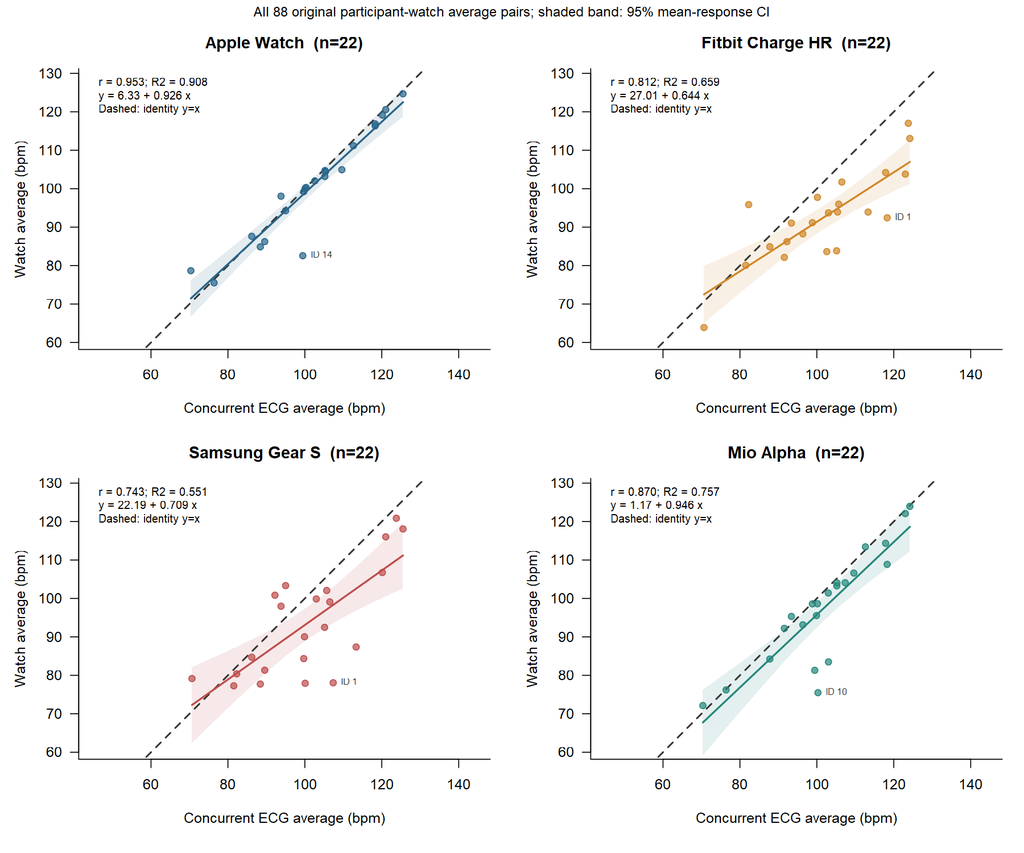

| 기기 | n | Pearson r | 95%CI | 원문 대조용 Spearman |
| --- | --- | --- | --- | --- |
| Apple Watch | 22 | 0.953 | 0.888 ~ 0.981 | 0.975 |
| Fitbit Charge HR | 22 | 0.812 | 0.594 ~ 0.919 | 0.767 |
| Samsung Gear S | 22 | 0.743 | 0.467 ~ 0.887 | 0.670 |
| Mio Alpha | 22 | 0.870 | 0.709 ~ 0.945 | 0.871 |

**연결 근거**

paper Statistical analysis and Table 1 footnote; S1 Heart_Rate

문제 ID: S01, S02, C01

concept MD 열기 · paper MD 열기

04

## 단순 선형회귀

일반 원리를 먼저 읽고, 같은 단계의 원문·구현·결과를 확인합니다.

CONCEPT · 일반 통계 개념

원리·공식·가상 계산·가정·대안 — 특정 논문과 독립적으로 읽는 설명

### 입력 → 질문

입력은 연속형 x·y의 짝입니다. 단순회귀는 “x가 주어질 때 y의 평균이 어떻게 변하는가?”를 원래 측정 단위로 기술합니다. 상관이 단위 없는 관계의 정도라면 기울기는 x 1단위 증가에 따른 평균 y 변화입니다.

### 방법과 이유: 최소제곱

`yᵢ=a+b·xᵢ+εᵢ`, `ŷᵢ=a+b·xᵢ`, `잔차 uᵢ=yᵢ−ŷᵢ`입니다. OLS는 잔차 제곱합을 작게 하며 `b=Sxy/Sxx`, `a=ȳ−b·x̄`입니다. 잔차는 회귀선에서 벗어난 정도이고, 측정오차 y−x와 구별합니다.

### 최소 공식과 작은 계산 — 가상 예제

가상 x=(1,2,3), y=(2,2,5)에서 x̄=2, ȳ=3, Sxx=2, Sxy=3입니다. 따라서 b=1.5, a=0이고 적합값은 (1.5,3,4.5), 잔차는 (0.5,−1,0.5)입니다. 잔차 제곱합 1.5, y의 총제곱합 6이므로 R²=1−1.5/6=0.75입니다. 이것은 측정값 75%가 정확하다는 뜻이 아닙니다.

### 가정·CI·대안이 답하는 질문

일반적인 계수 CI는 선형 평균 관계, 독립 오차, 등분산과 작은 표본에서의 정규 오차 조건을 점검하며 해석합니다. OLS 계수의 적합 자체에는 오차의 정규성이 필요하지 않습니다. x는 주어진 기준으로 취급하므로 양쪽 측정오차가 중요한 질문에는 다른 접근이 필요할 수 있습니다.

평균반응 CI는 회귀선 평균의 불확실성입니다. 새 개인의 예측구간은 잔차 변동도 포함하고, 두 방법 차이의 LoA와도 다릅니다. x·y를 바꾸면 회귀식은 일반적으로 역수가 되지 않습니다. 보정·미래 예측을 주장하려면 사용 방향과 별도 평가가 필요합니다.

### 출력 → 남은 질문

회귀식·계수 CI·R²·관측 범위·잔차를 보고합니다. 절편 있는 단순 OLS에서는 R²=r²이지만 두 지표가 다른 정보를 독립적으로 검증한 것은 아닙니다. 다음에는 동일값 기준 y=x에서 얼마나 벗어나는지 확인합니다.

↓ 같은 질문을 실제 자료에 적용

PAPER · 논문·실제 데이터 적용

원문 사실 · 이번 구현의 선택 · 실제 출력 · 남은 의문

### 입력 → 이번 질문

이번 과제는 각 시계 평균을 y, 동시 ECG 평균을 x로 둔 단순 OLS를 기기마다 적합했습니다. 질문은 관측 범위에서의 평균적 관계입니다. ECG를 시계로부터 예측하는 외부 보정 성능을 평가한 분석은 아닙니다.

### 논문 방법과 이번 과제의 구분

원문도 회귀를 사용하지만 차이·일치한계를 두 측정의 평균과 연결하는 Bland–Altman 회귀 맥락입니다. 여기의 시계~ECG 단순 OLS, 계수 CI·적합 R²는 과제 구현입니다. 이 결과를 원문의 동일 회귀계수 재현이라고 쓰지 않습니다.

### 이번 구현의 선택과 이유

R lm으로 절편을 포함해 22명 모두 적합했습니다. 산점도에는 OLS와 y=x, 평균반응 95%CI를 함께 그렸습니다. R²=r²를 수식 검산했으며 평균반응 음영을 개인 예측구간으로 해석하지 않았습니다.

### 출력·검토 결과

아래 실제 회귀식은 ECG가 100bpm일 때의 적합 평균도 보여 줍니다. 적합도가 높아도 y=x와 차이가 있으면 측정값의 일치는 별도로 확인해야 합니다. 회귀선 그림은 직전 산점도 패널과 공유합니다.

### 남은 의문과 다음 단계

S02·S05에 연결됩니다. ECG도 완전한 무오차 참값이라고 입증한 것은 아니며 작은 표본·공유 참가자·외부 평가 부재가 남습니다. 잔차 진단은 후속 보조 단계이고, 수치가 좋아지도록 표본을 삭제하지 않았습니다.

앞 단계의 전체 산점도·OLS·y=x 그림 보기

| 기기 | 회귀식 (시계 = a + b×ECG) | 기울기 95%CI | R² | ECG100에서 적합값 |
| --- | --- | --- | --- | --- |
| Apple Watch | 6.33 + 0.926 × ECG | 0.788 ~ 1.063 | 0.908 | 98.89 |
| Fitbit Charge HR | 27.01 + 0.644 × ECG | 0.428 ~ 0.860 | 0.659 | 91.39 |
| Samsung Gear S | 22.19 + 0.709 × ECG | 0.411 ~ 1.007 | 0.551 | 93.09 |
| Mio Alpha | 1.17 + 0.946 × ECG | 0.696 ~ 1.196 | 0.757 | 95.77 |

**연결 근거**

course extension: device~ECG OLS; distinguish paper Statistical analysis / Bland–Altman regression

문제 ID: S02, S05

concept MD 열기 · paper MD 열기

05

## 측정오차·일치도

일반 원리를 먼저 읽고, 같은 단계의 원문·구현·결과를 확인합니다.

CONCEPT · 일반 통계 개념

원리·공식·가상 계산·가정·대안 — 특정 논문과 독립적으로 읽는 설명

### 입력 → 질문

입력은 동일 대상의 두 측정값입니다. “차이가 어느 방향이며 평균적으로 얼마나 크고, 개별 차이가 얼마나 퍼지는가?”를 묻습니다. 오차의 부호를 먼저 정해야 과소·과대 추정의 뜻이 일관됩니다.

### 방법과 이유: 방향·크기·분포

`e=y−x`, `bias=mean(e)`, `MAE=mean(|e|)`, `RMSE=√mean(e²)`입니다. bias는 방향, MAE는 상쇄 없는 크기, RMSE는 제곱으로 큰 차이에 더 무게를 주는 크기입니다. 히스토그램은 비대칭·꼬리·큰 오차를 보여 줍니다.

### 최소 공식과 작은 계산 — 가상 예제

가상 오차 (−2,0,+2)이면 bias=0이지만 MAE=4/3≈1.33, RMSE=√(8/3)≈1.63입니다. 따라서 평균오차 0은 모든 측정이 같다는 뜻이 아닙니다. 이 세 숫자는 원리 설명용이며 실제 참가자 결과가 아닙니다.

### Bland–Altman과 불확실성

차이를 세로축, 두 측정의 평균 (x+y)/2를 가로축으로 놓습니다. 차이가 대략 정규이고 측정 크기 전반에서 분포가 안정적이면 고정 일치한계는 `bias±1.96·SD(e)`로 추정합니다. 이는 평균 차이의 CI가 아닙니다. 추정된 LoA 자체도 표본 불확실성이 있으며, 모든 미래 차이가 반드시 안에 든다는 보장은 없습니다.

### 가정·대안이 답하는 질문

측정 크기에 따라 차이·분산이 달라지면 고정 LoA 해석이 제한됩니다. 변환이나 회귀에 따른 가변 한계는 그 다른 구조를 다루지만 동일한 숫자로 비교할 수는 없습니다. 임상적 허용 범위는 통계에서 자동으로 생기지 않으므로 별도의 사용 목적·기준이 필요합니다.

### 출력 → 남은 질문

bias·MAE·RMSE와 차이 분포·LoA를 함께 보고합니다. 평균오차 CI가 0을 포함해도 동등성·교환 가능성이 증명되는 것은 아닙니다. 평균 집계 이전의 순간 오차도 이 지표만으로 복원할 수 없습니다.

↓ 같은 질문을 실제 자료에 적용

PAPER · 논문·실제 데이터 적용

원문 사실 · 이번 구현의 선택 · 실제 출력 · 남은 의문

### 입력 → 이번 질문

이번 계산은 시계−ECG를 오차로 고정했습니다. 네 기기에 대해 22쌍씩 bias·MAE·RMSE·오차 SD·평균오차 t CI·MAPE와 고정 Bland–Altman LoA를 계산했습니다. 음수는 이 정의에서 과소추정입니다.

### 논문 방법과 이번 구현의 구분

원문은 Bland–Altman 일치도를 다룹니다. 특히 Mio의 상·하한은 평균 크기의 함수로 제시되어 있습니다. 이번 고정 LoA·MAE·RMSE·공통 구간 히스토그램은 과제의 기술·보조 분석이며 원문의 가변 한계까지 완전히 재현한 결과가 아닙니다.

### 출력·검토 결과

아래 실제 결과에서 네 기기의 표본 bias는 음수였습니다. Apple도 bias가 비교적 작다는 사실만으로 순간 측정이나 임상 사용에서 오차가 없다고 할 수 없습니다. 같은 축의 오차 분포와 차이 대 평균 그림을 함께 확인합니다.

### 남은 의문과 다음 단계

S02·S03·C03에 연결됩니다. 집계된 평균의 오차이고 임상 허용 기준은 정하지 않았습니다. 고정 LoA의 분포 가정과 크기 의존성은 진단을 통해 제한을 점검하되 불확실성이 해소되었다고 단정하지 않습니다.

### 기기별 오차 히스토그램

모든 기기에서 같은5bpm 구간과 같은 축을 사용했습니다. 검은 점선0과 색 실선 평균오차를 비교합니다. 양·음 오차가 상쇄될 수 있어 평균오차만으로 정확도를 판정하지 않습니다.

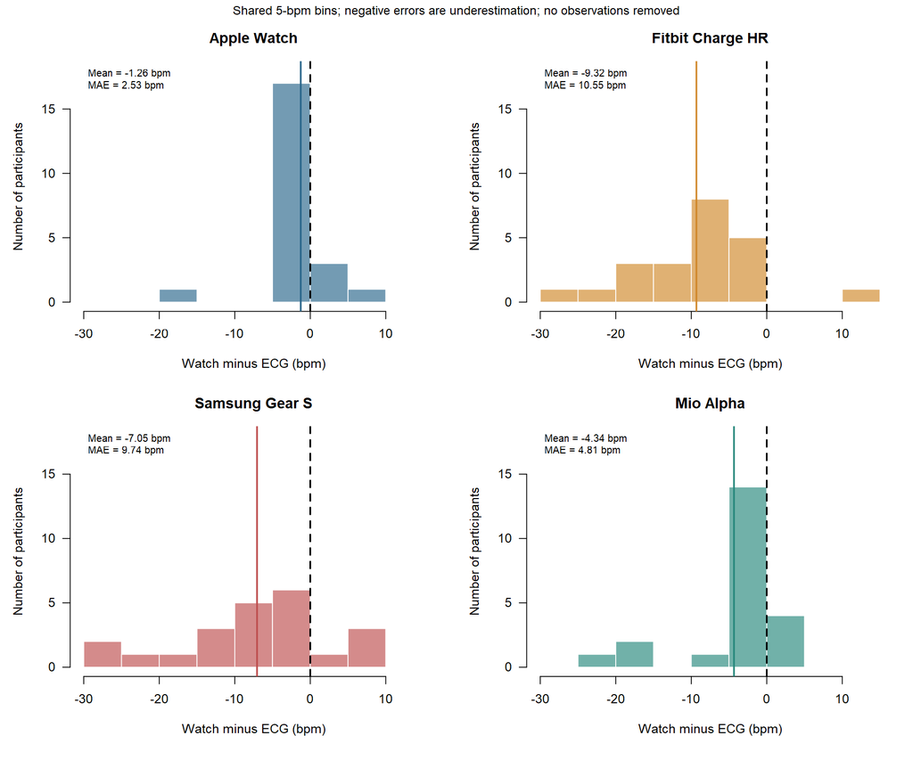

### 오차 방향과 크기

왼쪽은 평균오차와 점별95% t CI, 오른쪽은 MAE입니다. 신뢰구간이0을 포함한다는 사실은 개별 측정값의 일치나 임상적 교환 가능성을 증명하지 않습니다.

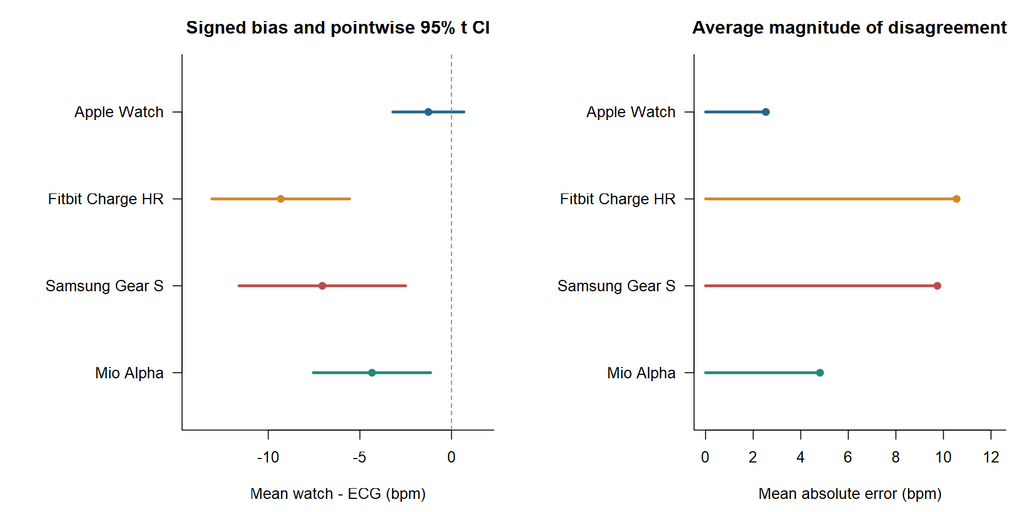

| 기기 | 평균오차 | 평균오차 95%CI | 오차 SD | 고정 LoA 하한 | 고정 LoA 상한 | MAPE % |
| --- | --- | --- | --- | --- | --- | --- |
| Apple Watch | -1.26 | -3.20 ~ 0.68 | 4.38 | -9.84 | 7.32 | 2.70 |
| Fitbit Charge HR | -9.32 | -13.08 ~ -5.56 | 8.48 | -25.94 | 7.30 | 10.09 |
| Samsung Gear S | -7.05 | -11.60 ~ -2.50 | 10.26 | -27.15 | 13.06 | 9.63 |
| Mio Alpha | -4.34 | -7.54 ~ -1.14 | 7.22 | -18.49 | 9.80 | 4.72 |

### 차이 대 두 측정 평균

가로축은 (시계+ECG)/2, 세로축은 시계−ECG입니다. 색 실선은 평균오차, 붉은 점선은 고정LoA, 색 점선은 오차~평균 진단선입니다. 고정LoA는 기술적 보조 분석으로 원문의 회귀 가변LoA와 구별합니다.

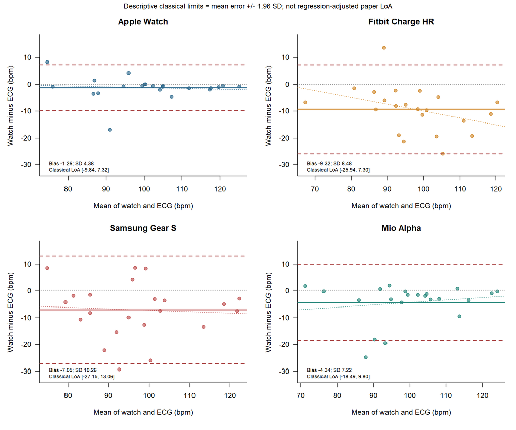

MAPE는 개인별 절대 상대오차의 평균입니다. 논문의 다른 백분율 요약과 정의를 대조하지 않고 직접 같다고 해석하지 않습니다. LoA는 연구의 분포 요약이며 이번 과제에서 정한 임상 허용 기준은 없습니다.

**연결 근거**

paper Statistical analysis, Table 1, Figure 2; S1 Heart_Rate

문제 ID: S02, S03, C03

concept MD 열기 · paper MD 열기

06

## 진단·영향점·민감도

일반 원리를 먼저 읽고, 같은 단계의 원문·구현·결과를 확인합니다.

CONCEPT · 일반 통계 개념

원리·공식·가상 계산·가정·대안 — 특정 논문과 독립적으로 읽는 설명

### 입력 → 질문

입력은 적합한 모형과 관측별 잔차입니다. “선형·분산 가정에 어긋나는 구조가 있는가, 한 사람이 결론을 크게 움직이는가?”를 묻습니다. 결과가 마음에 드는지를 평가하는 절차와 구분합니다.

### 방법과 이유

잔차 대 적합값에서는 곡선·깔때기 모양·군집을, Q–Q에서는 정규 모형 대비 꼬리·비대칭을 봅니다. 이상치는 큰 잔차, 높은 leverage는 특이한 x 위치, 영향점은 추정값을 크게 움직이는 관측입니다. Cook 거리는 영향의 한 지표이며 자동 삭제 명령이 아닙니다.

### 최소 공식과 작은 계산 — 가상 예제

가상 값 (4,6,8,22)의 전체 평균은 10입니다. 22를 제외하면 (4+6+8)/3=6입니다. 한 관측이 평균에 영향을 준다는 설명이지 22가 오류이거나 삭제해야 한다는 증거는 아닙니다.

### 가정·대안·민감도의 범위

한 명씩 제외해 관심 통계량을 다시 구하면 특정 관측 의존성을 볼 수 있습니다. 이 최솟값~최댓값은 CI가 아니며, 제외한 사람의 미래 예측 오차를 평가하지 않았다면 예측 교차검증 점수도 아닙니다. 작은 표본에서 정규성 p값 하나로 가정을 확정하거나 방법을 자동 교체하지 않습니다.

### 출력 → 남은 질문

전체 분석과 별도 민감도를 나란히 보고합니다. 오류 확인·설계 근거가 있어 자료를 바꾼 경우에만 새 버전과 하류 결과를 갱신합니다. 영향 확인만으로 표본을 선별하거나 성능 향상을 주장하지 않습니다.

↓ 같은 질문을 실제 자료에 적용

PAPER · 논문·실제 데이터 적용

원문 사실 · 이번 구현의 선택 · 실제 출력 · 남은 의문

### 입력 → 이번 질문

이번 잔차·Q–Q·Cook·한 명씩 제외하는 분석은 과제의 추가 진단입니다. 원문에서 동일한 진단 결과를 보고했다고 주장하지 않습니다. 주 분석 22명씩은 그대로 두고 관측 하나에 대한 민감도를 확인했습니다.

### 이번 구현의 선택과 이유

기기별 22개 제외 시나리오, 총 88개 보조 적합에서 상관·기울기 등의 범위를 저장했습니다. 더 높은 r를 만드는 시나리오를 최종 결과로 고르지 않았습니다. 오차~두 측정 평균 진단선도 크기 의존성을 살피는 보조 요약입니다.

### 출력·검토 결과

아래 범위와 그림은 실제 저장된 전체·제외 시나리오 결과입니다. STYLE1의 축·기기명·ID 표시 수정은 같은 잔차 CSV를 다시 그린 서식 수정이며 통계 재적합은 없었습니다. 수치와 최초 그림은 run 안에 보존됩니다.

### 남은 의문과 다음 단계

S03–S05에 연결됩니다. 작은 표본의 진단은 정규성·등분산·외부 예측을 입증하지 못합니다. 원문과의 차이는 다음 단계에서 같은 정의·통계 종류인지 먼저 대조합니다.

### 회귀 잔차 대 적합값

직선 주위에 구조·분산 차이가 보이는지 읽습니다. 표기한 ID는 Cook 거리가 가장 큰 참가자이며 자동 제외 기준으로 사용하지 않았습니다.

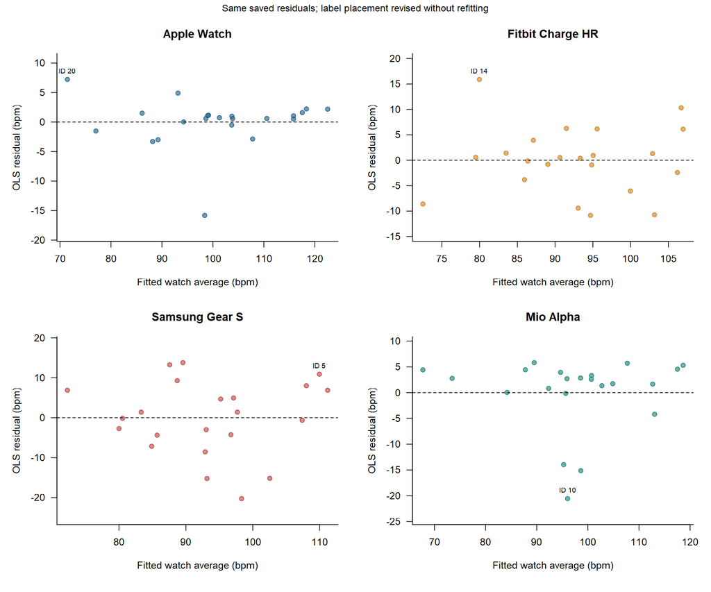

### 잔차 Q-Q 진단

정규분포에서의 이탈과 꼬리를 점검합니다. 작은 표본의 진단 p값 하나로 분석법을 바꾸거나 문제가 없다고 확정하지 않습니다.

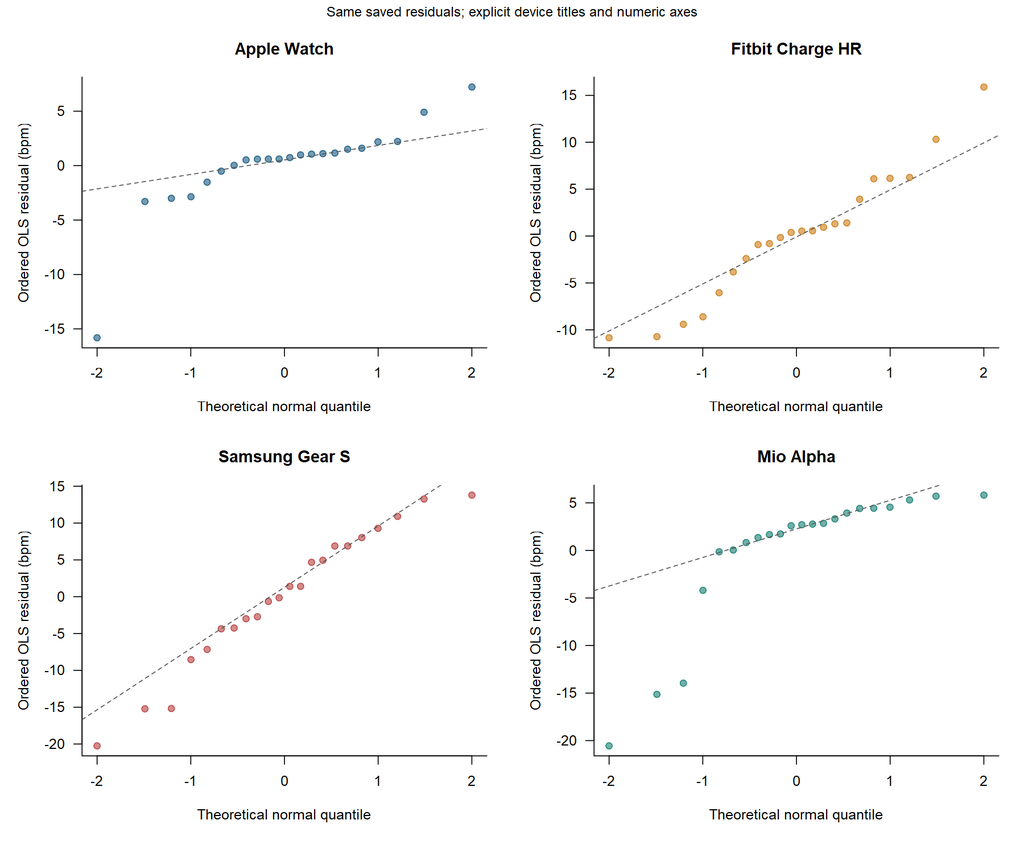

| 기기 | 한 명씩 제외 r 범위 | 기울기 범위 | r 변화가 가장 큰 ID |
| --- | --- | --- | --- |
| Apple Watch | 0.944 ~ 0.985 | 0.911 ~ 0.998 | 14 |
| Fitbit Charge HR | 0.747 ~ 0.874 | 0.561 ~ 0.725 | 20 |
| Samsung Gear S | 0.697 ~ 0.797 | 0.641 ~ 0.770 | 1 |
| Mio Alpha | 0.848 ~ 0.915 | 0.908 ~ 1.000 | 10 |

### 한 명씩 제외하는 민감도

선은22개 제외 시나리오의 최소~최대이고 점은 전체22명 결과입니다. 이 범위는 신뢰구간이 아니며, 기기별21명 결과를 최종 주 분석으로 선택하지 않았습니다. 88개의 보조 적합은 holdout 예측 검증을 뜻하지 않습니다.

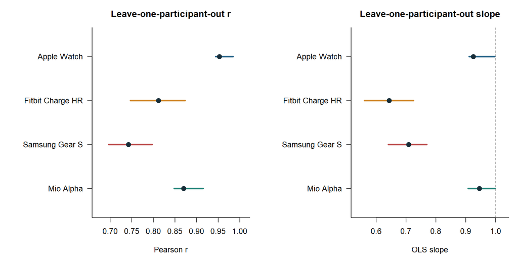

**연결 근거**

analyst supplemental diagnostics; frozen R1 tables and STYLE1 rendering manifest

문제 ID: S03, S04, S05

concept MD 열기 · paper MD 열기

07

## 논문 수치 대조·해석

일반 원리를 먼저 읽고, 같은 단계의 원문·구현·결과를 확인합니다.

CONCEPT · 일반 통계 개념

원리·공식·가상 계산·가정·대안 — 특정 논문과 독립적으로 읽는 설명

### 입력 → 질문

입력은 출판값과 직접 계산값입니다. “같은 자료·대상·정의·통계·단위의 값을 비교하는가, 차이는 어디에서 생기는가?”를 먼저 묻습니다. 숫자가 가깝다는 사실과 원래 구현을 확인했다는 사실은 다릅니다.

### 방법과 이유: 비교 계약

분모·선정·변환·부호·상관 종류·CI와 한계의 종류를 맞춥니다. `Δ=계산값−출판값`, `|Δ|≤허용오차`로 판정하되 허용오차의 근거와 정한 시점을 적습니다. 결과를 본 뒤 만든 설명은 사후 점검으로 표시합니다.

### 최소 공식과 작은 계산 — 가상 예제

가상 원값 98.246을 소수 첫째 자리까지 인쇄하면 98.2입니다. 직접 계산값과의 차이 0.046은 0.05 이내입니다. 반올림과 양립하지만 계산 과정이 같았다는 증명은 아닙니다. 다른 통계량끼리는 우연히 숫자가 같아도 재현 일치로 세지 않습니다.

### 가정·대안이 답하는 질문

차이가 나면 자료 버전·분모·정의·반올림·코드를 확인합니다. 미공개 설정은 미확인으로 남길 수 있습니다. 수치 재현 검토는 “원문 결과와 맞는가?”, 타당성 검토는 “질문·자료에 방법과 해석이 적절한가?”라는 별개 질문입니다.

### 출력 → 남은 질문

같은 정의의 비교표, 일치·차이·비교 불가의 이유, 확인한 범위를 남깁니다. 출판 숫자에 가까워지도록 원값이나 주 방법을 바꾸지 않습니다. 일부 수치 일치는 논문 전체·임상 효용·분석 타당성 전체의 증명이 아닙니다.

↓ 같은 질문을 실제 자료에 적용

PAPER · 논문·실제 데이터 적용

원문 사실 · 이번 구현의 선택 · 실제 출력 · 남은 의문

### 입력 → 이번 질문

공식 원문 Table 1과 Figure 2를 고정된 R1 결과와 대조했습니다. 이번 비교 범위는 공개 HR 요약치 일부이며 ICC·에너지 소비·걸음 수와 논문 전체의 재현이 아닙니다.

### 논문 원문과 직접 계산의 구분

Samsung 원문의 0.67은 Spearman입니다. 같은 종류로 대조하면 상관 4개는 허용오차 0.005 이내입니다. 과제 Pearson 0.743은 그대로 유지했습니다. Mio의 원문 가변 LoA는 이번 상수 LoA와 직접 동등 판정하지 않았습니다.

### 이번 비교 선택과 결과

n·r·평균의 허용오차는 실행 전 계획에 있었고, SD·LoA의 0.05는 원문 표 추출 후 소수 첫째 자리 정밀도에 적용했습니다. 38개 필드 중 33개가 각 허용오차 이내이며 이 비율을 정확도 점수로 해석하지 않습니다.

### 남은 의문

C01–C03에 연결됩니다. 인쇄된 bias·SD를 대입한 고정 LoA 6개가 원문과 양립하는지는 사후 설명 점검입니다. 저자의 실제 반올림 순서는 미확인이고 원자료 계산값은 수정하지 않았습니다.

| 기기 | 과제 Pearson | 원문 종류 | 원문 값 | 같은 종류 계산 | 판정 |
| --- | --- | --- | --- | --- | --- |
| Apple Watch | 0.952930 | Pearson | 0.95 | 0.952930 | 허용오차 내 |
| Fitbit Charge HR | 0.812046 | Pearson | 0.81 | 0.812046 | 허용오차 내 |
| Samsung Gear S | 0.742585 | Spearman | 0.67 | 0.670243 | 허용오차 내 |
| Mio Alpha | 0.870193 | Pearson | 0.87 | 0.870193 | 허용오차 내 |

**Samsung 0.743과0.67은 통계 종류가 다릅니다.**

원문 Table1의 별표는 Spearman을 뜻합니다. 원문 방식 상관4개는 반올림 허용오차0.005 안에서 맞습니다. 과제에서 요구한 Pearson은 모든 기기에 그대로 보고하고, 더 가까운 값을 얻으려고 분석법을 교체하지 않았습니다.

N·평균·SD·원문 방식 상관·세 기기의 고정LoA 등 총38개 필드 중33개가 명시한 반올림 허용오차 안에 있습니다. n·r·평균 기준은 실행 전 계획에 고정했고, SD·LoA의0.05는 표 추출 후1자리 표기 정밀도에 적용했습니다. 개별 차이는 아래와 같으며 이 개수를 정확도의 점수로 읽지 않습니다.

| 기기 | 비교 항목 | 원문 | 직접 계산 | 차이 |
| --- | --- | --- | --- | --- |
| Samsung Gear S | bias | -7.1 | -7.048182 | 0.051818 |
| Apple Watch | classical_loa_low | -9.9 | -9.836879 | 0.063121 |
| Fitbit Charge HR | classical_loa_high | 7.4 | 7.300741 | -0.099259 |
| Fitbit Charge HR | classical_loa_low | -26.0 | -25.936196 | 0.063804 |
| Samsung Gear S | classical_loa_low | -27.3 | -27.152278 | 0.147722 |

### 작은 차이: 반올림과 양립하는 설명

인쇄된1자리 평균오차·SD를 LoA 식에 대입하면 세 기기의 고정LoA6개가 출판값0.05 이내로 나옵니다. 이는 사후 설명 점검이며, 저자의 원래 계산 순서를 입증하지는 않습니다. 직접 계산한 주 결과와 원본 값은 유지했습니다.

### 방법 차이: Mio의 가변 일치한계

원문은 상한 −0.44×평균+52.69, 하한0.4×평균−61.2를 제시합니다. 평균 크기에 따라 달라지는 식을 이번 고정LoA와 같은 결과로 비교할 수 없습니다.

상관·요약치 재현은 확인됐지만 반올림·일치한계의 세부 차이는 남습니다. ICC·에너지 소비·걸음 수 재현과는 구분됩니다.

**연결 근거**

paper Table 1, Figure 2, Statistical analysis; sources/published_tables.json

문제 ID: C01, C02, C03

concept MD 열기 · paper MD 열기

08

## 문제·검증·보고의 한계

일반 원리를 먼저 읽고, 같은 단계의 원문·구현·결과를 확인합니다.

CONCEPT · 일반 통계 개념

원리·공식·가상 계산·가정·대안 — 특정 논문과 독립적으로 읽는 설명

### 입력 → 질문

입력은 분석의 자료·실행·근거·변경 기록입니다. “어떤 문제가 있었고, 무엇을 수정했으며, 결론은 어디까지 뒷받침되는가?”를 묻습니다. 소프트웨어 실행 성공, 수치 검산, 통계적 타당성, 임상 적용 가능성은 서로 다른 확인 범위입니다.

### 방법과 이유: 문제와 변경을 연결

문제를 자료 정의·환경/코드·방법/해석·출판 비교로 구분합니다. ID마다 발견 근거, 조치, 영향받는 산출물, 해결 여부와 남은 의문을 남깁니다. 새 자료·선정·코드가 수치를 바꾸면 하류 표·그림·해석을 갱신하고, 문구·서식만 바꾸면 해당 설명·화면을 검토합니다.

### 최소 공식과 작은 계산 — 가상 예제

가상으로 입력 1,000행에서 중복 20행을 제외했다면 분석 분모는 980행입니다. 보고서는 `입력−제외=사용`을 설명하고 이전 1,000행 결과와 섞지 않아야 합니다. 이 수치는 설명용이며 이번 연구의 제외 내역이 아닙니다.

### 가정·대안이 답하는 질문

해시 일치는 파일 무결성, 별도 수식 대조는 계산 일관성에 관한 근거입니다. 독립된 검토자·새 표본·맹검 평가를 수행했는지는 별도로 기록합니다. 미확인을 실행 실패와 섞지 않으며 유의하지 않음도 실패로 부르지 않습니다.

### 출력 → 남은 질문

완료·미확인·적용 범위가 명확한 보고서가 출력입니다. 일반 개념과 특정 논문 적용을 짝지어 학습하되 같은 HTML에 담는 것은 전달 형식의 선택입니다. 관측 결과에서 직접 나오지 않는 인과·미래 예측·임상 우열은 추가 증거가 필요한 질문으로 남깁니다.

↓ 같은 질문을 실제 자료에 적용

PAPER · 논문·실제 데이터 적용

원문 사실 · 이번 구현의 선택 · 실제 출력 · 남은 의문

### 입력 → 이번 질문

이번 프로젝트의 자료·통계·환경·원문 비교 문제 17개를 아래에 모았습니다. 각 학습 단계에도 해당 ID를 연결해 “개념 설명→실제 적용→의문→확인→업데이트된 해석”을 따라갈 수 있게 했습니다.

### 이번 수정의 범위

사용자의 요청에 따라 기존 concept/paper 학습 구조를 복원했습니다. 원본 XLSX, R1 통계·그림·CSV와 모든 실패·중간 기록은 유지합니다. 이번 변경은 설명·MD·HTML·문서 등록부의 갱신이며 통계 모형을 다시 적합하지 않았습니다.

### 출력·검토 결과

기존 R 수식·자료 28개 점검과 동일 에이전트의 Python 402개 대조를 보존합니다. 이를 외부·맹검·독립 에이전트의 원 분석 심사라고 부르지 않습니다. 새 HTML의 내용·레이아웃·전체 자료·그림·다운로드는 문서 수정 범위에서 다시 확인합니다.

### 남은 한계

집계된 평균, 작은 건강한 표본, 기기 간 공유 참가자, 현재 제품·일상생활·환자에 대한 일반화, 임상 허용 기준 부재, 원문 계산 정밀도와 Mio 가변 LoA의 차이가 남습니다. 다음의 17개 기록에서 해결 조치와 과학적으로 미확인인 부분을 구분합니다.

**D01원자료가 이미 참가자별 평균이다**

공개 HR 시트에는 활동·시각 열이 없습니다. 15초 자료를 임의 생성하지 않고 평균값88쌍 전부를 사용했습니다. 집계 수준 아래의 순간오차는 남는 한계입니다.

기록 상태: limitation retained

**D02Fitbit 기준열 이름과 설명이 다르다**

F1의 Fitbit_metamax 표기를 그대로 칼로리로 해석하면 단위·기준을 잘못 짝지을 수 있습니다. Key의 Worksheet_4와 논문방법 근거로 ECG bpm에 매핑하고 원본은 보존했습니다.

기록 상태: resolved for analysis

**D03Trial_number가 네 번 반복된다**

자동 이름 변경을 믿지 않고 원래 헤더와 B–D/E–G/H–J/K–M 위치를 확인했습니다. 기기마다 동시trial 기준값을 사용했습니다.

기록 상태: controlled

**D04성별 코드가 Key와 시트에서 다르다**

Demographics 표기는1/2, Key는0/1입니다. 이번 HR 분석에 성별을 사용하지 않았으며 임의 수정하지 않았습니다. 범위 밖 메타데이터 문제로 남깁니다.

기록 상태: outside assignment; unresolved

**S0188쌍은88명이 아니다**

기기별22명 분석을 수행했습니다. 기기 간 같은 사람이 반복되므로 합친88행을 독립 사람으로 취급한 p값이나 독립표본 우열 검정을 만들지 않았습니다.

기록 상태: controlled

**S02상관이 높으면 일치도 높은가**

고정 오차·배율 차이가 있어도 r는 높을 수 있습니다. y=x, 평균오차, MAE, RMSE, 히스토그램과LoA를 함께 해석했습니다.

기록 상태: analysed in outputs

**S03고정LoA와 회귀 가변LoA는 다르다**

이번 고정LoA는 보조 기술치입니다. 원문의 Mio 회귀 가변 식을 완전히 재현했다고 표현하지 않습니다. 크기에 따른 분산 변화·비정규성과 평균 집계의 한계가 남습니다.

기록 상태: limitation retained

**S04큰 오차 참가자를 삭제할 것인가**

소스에 근거한 제외 사유가 없어88쌍 전부 유지했습니다. 한 명씩 제외한 별도 민감도만 보존했고 더 높은 r를 주 결과로 선택하지 않았습니다.

기록 상태: controlled

**S05OLS가 보정 성능·참값을 증명하는가**

OLS는 기준x를 주어진 값으로 두는 기술 모형입니다. ECG 측정오차, 작은 표본, 외부 자료 부재를 고려해야 합니다. 적합R²·LOO민감도를 실제 미래 예측 성능으로 주장하지 않습니다.

기록 상태: limitation retained

**E01readxl 패키지 준비**

초기에는 readxl이 없어 프로젝트 전용R라이브러리에1.6.0을 설치했습니다. 환경 버전과 실제 실행을 기록했고 전역 패키지를 변경하지 않았습니다.

기록 상태: resolved

**E02DOI·슬라이드의 최초 웹 읽기 실패**

공식 출판사 데이터 endpoint와 공개 슬라이드 직접 다운로드로 확보했습니다. 원본 byte·SHA256·영구 출처를 보존했습니다.

기록 상태: resolved

**E03OpenPyXL 확장 경고**

읽기 도구가 저장 시 Excel 확장을 보존하지 못한다는 경고입니다. 읽기 전용으로만 사용하고 원본을 재저장하지 않았으며 내용 해시가 같음을 확인했습니다.

기록 상태: controlled

**E04보조 검사 경로를 잘못 선택했다**

폴더 이름 끝부분 검색이 다른 프로그래밍 폴더를 선택해 읽기 실패했습니다. 명시한 절대경로로 교정했고 R 주 분석 전에 해결했습니다. 이 실패로 값이 수정되지는 않았습니다.

기록 상태: resolved

**D05Key의 Integer 표기와 실제 소수값**

심박수 평균에는 소수가 있습니다. 원자료의 소수와 전체 정밀도를 유지하고 통계를 위한 정수 변환·사전 반올림을 하지 않았습니다.

기록 상태: controlled

**C01Samsung 원문은 Spearman이다**

원문 각주를 확인해0.67의 종류를 구분했습니다. 보조 Spearman0.670243을 비교하되 주Pearson0.742585는 유지했습니다.

기록 상태: resolved without tuning

**C02원문과 작은 요약치·LoA 차이**

삼성 평균오차와 일부 고정LoA가 허용오차 밖입니다. 인쇄된 평균오차·SD를 사용한 반올림 호환 점검은 별도로 기록했습니다. 원값을 조정하지 않았고 원래 정밀도·계산 과정은 미확인입니다.

기록 상태: partial; original precision/rounding procedure unknown

**C03Mio 일치한계가 평균의 함수다**

논문에 기울기가 있는 상·하한 방정식이 있습니다. 상수LoA와의 직접 일치 판정은 하지 않습니다. 과제 범위의 기술 분석과 저자 전체 방법 재현은 다릅니다.

기록 상태: not directly comparable; limitation retained

**최종 해석의 범위**

이 자료는 소수 참가자의 실험실 평균자료입니다. 평균이 순간오차를 가릴 수 있으며, 현재 판매 제품·질환자·일상생활·활동별 정확도로 일반화할 수 없습니다. 임상 허용 기준이나 인과효과·외부 예측 성능을 확정한 분석도 아닙니다.

검산은 동일 에이전트가 수행한 R 수식 점검과 Python 교차 계산입니다. 별도 사람·외부 표본·맹검 심사를 했다고 표시하지 않습니다.

**연결 근거**

analysis/memory/issues.json; run/status.json and cross-check outputs; user correction 2026-10-24

문제 ID: D01, D02, D03, D04, S01, S02, S03, S04, S05, E01, E02, E03, E04, D05, C01, C02, C03

concept MD 열기 · paper MD 열기

09

## 전체88쌍과 단계별 기록

자료를 임의로 줄이지 않았는지 원래 셀·ID·trial·오차로 확인할 수 있습니다. 아래 필터는 표시만 바꾸고 분석값을 바꾸지 않습니다.

자료 표시:88 / 88쌍

| ID | 기기 | Trial | ECG bpm | 시계 bpm | 오차 bpm | 기준 셀 | 시계 셀 |
| --- | --- | --- | --- | --- | --- | --- | --- |
| 1 | Apple Watch | 1 | 118.29 | 116.34 | -1.95 | C2 | B2 |
| 2 | Apple Watch | 1 | 109.62 | 104.93 | -4.69 | C3 | B3 |
| 3 | Apple Watch | 1 | 93.80 | 98.05 | 4.25 | C4 | B4 |
| 4 | Apple Watch | 1 | 121.03 | 120.57 | -0.46 | C5 | B5 |
| 5 | Apple Watch | 2 | 118.28 | 116.86 | -1.42 | C6 | B6 |
| 6 | Apple Watch | 2 | 86.20 | 87.62 | 1.42 | C7 | B7 |
| 7 | Apple Watch | 2 | 102.59 | 102.02 | -0.57 | C8 | B8 |
| 8 | Apple Watch | 2 | 95.00 | 94.28 | -0.72 | C9 | B9 |
| 9 | Apple Watch | 2 | 88.42 | 84.87 | -3.55 | C10 | B10 |
| 10 | Apple Watch | 1 | 100.29 | 100.31 | 0.02 | C11 | B11 |
| 11 | Apple Watch | 1 | 105.23 | 104.71 | -0.52 | C12 | B12 |
| 12 | Apple Watch | 2 | 125.52 | 124.69 | -0.83 | C13 | B13 |
| 13 | Apple Watch | 1 | 112.63 | 111.18 | -1.45 | C14 | B14 |
| 14 | Apple Watch | 2 | 99.46 | 82.57 | -16.89 | C15 | B15 |
| 15 | Apple Watch | 2 | 76.40 | 75.52 | -0.88 | C16 | B16 |
| 16 | Apple Watch | 1 | 89.57 | 86.23 | -3.34 | C17 | B17 |
| 17 | Apple Watch | 1 | 105.19 | 103.18 | -2.01 | C18 | B18 |
| 18 | Apple Watch | 2 | 120.15 | 119.13 | -1.02 | C19 | B19 |
| 19 | Apple Watch | 2 | 100.08 | 100.06 | -0.02 | C20 | B20 |
| 20 | Apple Watch | 1 | 70.36 | 78.67 | 8.31 | C21 | B21 |
| 21 | Apple Watch | 1 | 105.37 | 104.45 | -0.92 | C22 | B22 |
| 22 | Apple Watch | 1 | 99.71 | 99.22 | -0.49 | C23 | B23 |
| 1 | Fitbit Charge HR | 1 | 118.29 | 92.43 | -25.86 | F2 | E2 |
| 2 | Fitbit Charge HR | 2 | 105.13 | 83.84 | -21.29 | F3 | E3 |
| 3 | Fitbit Charge HR | 2 | 98.83 | 91.16 | -7.67 | F4 | E4 |
| 4 | Fitbit Charge HR | 2 | 117.88 | 104.20 | -13.68 | F5 | E5 |
| 5 | Fitbit Charge HR | 1 | 123.78 | 117.01 | -6.77 | F6 | E6 |
| 6 | Fitbit Charge HR | 1 | 87.77 | 84.91 | -2.86 | F7 | E7 |
| 7 | Fitbit Charge HR | 2 | 102.59 | 83.64 | -18.95 | F8 | E8 |
| 8 | Fitbit Charge HR | 1 | 103.02 | 93.71 | -9.31 | F9 | E9 |

[output cut: 58 more lines]

### Apple Watch

**전체 Pearson**

0.953

**평균오차 bpm**

-1.26

**MAE bpm**

2.53

**유지한 자료**

22 / 22쌍

원래 셀→상관→회귀→오차→진단→한계가 기기별MD에 연결됩니다.

기기별 MD 열기

### Fitbit Charge HR

**전체 Pearson**

0.812

**평균오차 bpm**

-9.32

**MAE bpm**

10.55

**유지한 자료**

22 / 22쌍

원래 셀→상관→회귀→오차→진단→한계가 기기별MD에 연결됩니다.

기기별 MD 열기

### Samsung Gear S

**전체 Pearson**

0.743

**평균오차 bpm**

-7.05

**MAE bpm**

9.74

**유지한 자료**

22 / 22쌍

원래 셀→상관→회귀→오차→진단→한계가 기기별MD에 연결됩니다.

기기별 MD 열기

### Mio Alpha

**전체 Pearson**

0.870

**평균오차 bpm**

-4.34

**MAE bpm**

4.81

**유지한 자료**

22 / 22쌍

원래 셀→상관→회귀→오차→진단→한계가 기기별MD에 연결됩니다.

기기별 MD 열기

### 학습 정본: concept / paper 7쌍 + 읽기 지도

일반 개념과 실제 적용의 14개 MD, 읽기 지도 1개입니다. 각 본문 패널에서도 같은 내용을 읽을 수 있습니다. 기존 과정·기기별 MD 14개는 이어지는 보조 기록에 보존했습니다. 모든 MD를 이 HTML에서 펼치거나 저장할 수 있습니다.

**학습 문서 읽기 지도 — concept / paper**

이 MD 저장

```
# 학습 문서 읽기 지도 — concept / paper

HTML 한 파일은 전달 형식입니다. 각 단계의 일반 통계 개념(concept)과 논문·실제 적용(paper) 구분은 유지합니다. 각 페이지는 입력→질문→방법과 이유→출력→남은 질문으로 연결합니다. 개념의 작은 계산은 가상이며 paper의 수치는 실제 R1 결과입니다.

읽는 순서는 학습 흐름이며 저자의 실행 순서나 통계 작업의 직렬 의존성을 뜻하지 않습니다. stage_registry.json의 execution_dependencies가 실제 산출물 관계를 별도로 표시합니다.

| 단계 | 일반 개념 | 논문·실제 적용 | 연결 의문 |
| --- | --- | --- | --- |
| HR01 자료·변수·관측 단위 | docs/learning/01-concept 자료·변수·관측 단위.md | docs/learning/01-paper 자료·변수·관측 단위.md | D01, D02, D03, D04, D05, S01 |
| HR02 산점도·Pearson 상관 | docs/learning/02-concept 산점도·Pearson 상관.md | docs/learning/02-paper 산점도·Pearson 상관.md | S01, S02, C01 |
| HR03 단순 선형회귀 | docs/learning/03-concept 단순 선형회귀.md | docs/learning/03-paper 단순 선형회귀.md | S02, S05 |
| HR04 측정오차·일치도 | docs/learning/04-concept 측정오차·일치도.md | docs/learning/04-paper 측정오차·일치도.md | S02, S03, C03 |
| HR05 진단·영향점·민감도 | docs/learning/05-concept 진단·영향점·민감도.md | docs/learning/05-paper 진단·영향점·민감도.md | S03, S04, S05 |
| HR06 논문 수치 대조·해석 | docs/learning/06-concept 논문 수치 대조·해석.md | docs/learning/06-paper 논문 수치 대조·해석.md | C01, C02, C03 |
| HR07 문제·검증·보고의 한계 | docs/learning/07-concept 문제·검증·보고의 한계.md | docs/learning/07-paper 문제·검증·보고의 한계.md | D01, D02, D03, D04, S01, S02, S03, S04, S05, E01, E02, E03, E04, D05, C01, C02, C03 |

기존 docs/00–09 및 docs/devices의 14개 문서는 과정·기기별 보조 기록으로 그대로 보존합니다. 학습의 정본은 docs/learning의 7쌍입니다. 모든 내용은 최종 HTML에도 내장됩니다.
```

**자료·변수·관측 단위 — 일반 통계 개념 (concept)**

이 MD 저장

```
# 자료·변수·관측 단위 — 일반 통계 개념 (concept)

이 문서의 숫자 예제는 모두 가상이며 실제 연구 결과가 아닙니다.

## 입력 → 질문

입력은 측정값과 코드북입니다. 계산 전에 “한 행은 누구의 어떤 시점·조건을 나타내며, 두 열은 같은 대상을 측정했는가?”를 묻습니다. 연속형 변수는 값의 크기와 차이에 의미가 있고, ID·기기명·trial은 관측을 구분하는 표지입니다.

## 방법과 이유: 단위·짝·독립성

측정 단위(예: bpm), 관측 단위(사람·사람×기기·사람×시점), 집계 수준(순간값·개인 평균)을 별도로 적습니다. 같은 사람의 두 측정은 짝을 이루고, 한 사람에게서 나온 여러 행은 서로 독립이라고 자동으로 가정할 수 없습니다.

wide→long 변환은 가로로 있던 기기별 열을 세로로 옮기는 구조 변경입니다. 값과 짝을 유지하면 그 자체가 표본 축소나 평균내기는 아닙니다. 반면 평균으로 집계하면 원래의 시간 변동 정보가 사라집니다.

## 최소 공식과 작은 계산 — 가상 예제

가상으로 3명에게 기기 2개를 측정하면 자료는 3×2=6행입니다. 기기마다 분석할 사람은 3명이고, 전체 행 수 6을 독립된 사람 수로 바꿀 수는 없습니다. 원래 값 80.4를 정수 80으로 바꾸는 일은 단순한 자료 배치 변경과도 다릅니다.

## 가정·대안이 답하는 질문

짝이 맞지 않으면 오차·상관 모두 다른 질문에 답합니다. 여러 시점의 변화를 묻는다면 시계열이나 반복측정 모형이 필요하고, 사람별 평균의 관계만 묻는다면 평균 자료가 직접 입력입니다. 결측은 누락 이유와 분모를 확인한 뒤 처리합니다.

## 출력 → 남은 질문

출력은 변수 사전, 한 행의 정의, 짝 매핑, 포함·제외·변환 내역입니다. 원래의 시간·활동 자료가 공개되지 않았다면 그 수준의 분석은 미확인으로 남깁니다.


짝 문서: 01-paper 자료·변수·관측 단위.md
```

**자료·변수·관측 단위 — 논문·실제 데이터 적용 (paper)**

이 MD 저장

```
# 자료·변수·관측 단위 — 논문·실제 데이터 적용 (paper)

학습 단계: HR01 · 관측 단위: 기기별 참가자 protocol 평균 · 자료 버전: wallen-hr-355eb8cf25fa3f49fd17 · 실행: R1-20261024

## 입력 → 이번 질문

논문은 건강한 참가자의 소비자용 시계를 ECG 기준과 비교합니다. 이번 입력은 S1의 Heart_Rate와 Key입니다. “공개된 참가자별 평균 심박수에서 시계와 해당 trial ECG의 관계·차이가 어떠한가?”로 과제 범위를 고정했습니다.

## 논문 원문·공개 자료에서 확인한 사실

공개 HR 시트는 22명의 protocol 평균입니다. 기기별 시계·ECG·trial 블록이 네 개이고, 15초 HR 시계열이나 활동별 HR 열은 없습니다. 논문의 세밀한 측정 절차와 공개 파일의 집계 수준을 구분했습니다.

## 이번 구현의 선택과 이유

원래 열 위치를 고정해 기기별 동시 ECG와 짝지었습니다. F1의 Fitbit_metamax는 Key Worksheet_4에서 ECG bpm으로 정의되어 그 근거로 매핑했습니다. ID·원래 헤더·행·셀·trial을 남겼으며 소수 정밀도를 유지했습니다. 22×4=88쌍을 모두 사용했고 제외·대체·추가 축약은 0입니다.

## 출력·검토 결과

아래 열 매핑과 실제 참가자 1의 변환은 공개 파일에 근거한 적용 예입니다. 가상 예제가 아닙니다. 원본 SHA256과 R·Python 대조는 자료·계산의 무결성 확인 범위이며 통계적 타당성 전체의 증명은 아닙니다.

## 남은 의문과 다음 단계

D01–D05·S01을 연결했습니다. 공개되지 않은 시간·활동 HR과 성별 코드 모순은 임의로 보완하지 않았습니다. 다음에는 이 관측 단위에서 산점도와 상관을 읽습니다.

## 실제 산출물

| 기기 | 시계 | 동시 ECG | trial |
| --- | --- | --- | --- |
| Apple Watch | B | C | D |
| Fitbit Charge HR | E | F | G |
| Samsung Gear S | H | I | J |
| Mio Alpha | K | L | M |

실제 결과: 22명, 기기별 22쌍, 총 88쌍; 주 분석 제외·대체·추가 축약 0. 원본 Heart_Rate 행 2–23.


출처 근거: S1 Dataset: Heart_Rate A1:M23, Key Worksheet_4; paper Methods / Experimental protocol

원본 결과: analysis/runs/R1-20261024/tables/heart_rate_pairs.csv

그림: 직접 연결 그림 없음

문제 ID: D01, D02, D03, D04, D05, S01

[논문](https://doi.org/10.1371/journal.pone.0154420) · [공개 XLSX](https://doi.org/10.1371/journal.pone.0154420.s001) · [수정 슬라이드](https://slides.pnucolab.com/9eGiQnmVQB7D)

짝 문서: 01-concept 자료·변수·관측 단위.md
```

**산점도·Pearson 상관 — 일반 통계 개념 (concept)**

이 MD 저장

```
# 산점도·Pearson 상관 — 일반 통계 개념 (concept)

이 문서의 숫자 예제는 모두 가상이며 실제 연구 결과가 아닙니다.

## 입력 → 질문

입력은 같은 관측 대상에서 얻은 연속형 x·y의 짝입니다. 산점도의 점 하나는 한 관측쌍이며, x·y축의 단위와 동일값 기준선 y=x를 먼저 확인합니다. 산점도는 관계의 방향·직선성·곡선·변동·큰 영향점을 보여 줍니다. Pearson r의 질문은 “두 값이 얼마나 강하게 직선 관계로 함께 변하는가?”입니다.

## 방법과 이유: 산점도와 표준화

`Sxx=Σ(x−x̄)²`, `Syy=Σ(y−ȳ)²`, `Sxy=Σ(x−x̄)(y−ȳ)`로 두면 `r=Sxy/√(Sxx·Syy)`입니다. r은 −1~1의 단위 없는 수이며, 부호는 방향, 절댓값은 직선 관계의 정도입니다. 한 변수가 상수이면 분모가 0이므로 r은 정의되지 않습니다.

## 최소 공식과 작은 계산 — 가상 예제

가상 x=(60,80,100), y=(70,90,110)이면 편차가 각각 (−20,0,20)입니다. Sxx=Syy=Sxy=800이므로 r=1입니다. 그러나 각 측정차 y−x는 모두 +10입니다. 아래 조작 예제도 가상 자료이며, 상관과 일치가 서로 다른 질문임을 보여 줍니다.

## 가정·불확실성·대안

표본 r 계산 자체와 모집단에 대한 CI·검정의 조건을 구분합니다. 일반적인 Pearson 검정·Fisher z CI는 독립적인 쌍과 적절한 분포 조건을 전제로 해석합니다. r은 효과 크기, CI는 추정의 불확실성, p값은 귀무가설(모상관=0)과 검정 모형 아래에서 관측값 이상으로 극단적인 결과가 나올 확률에 관한 값입니다. 작은 p가 큰 관계나 좋은 일치를 뜻하지 않습니다. 극단값·범위 제한·비선형성에 민감하고, 작은 표본에서 불확실성이 큽니다. r이 0이라고 비선형 관계가 없다는 뜻은 아닙니다.

Spearman은 순위의 단조 관계를 묻습니다. Pearson과 추정 대상이 달라 원문 숫자에 더 가깝다는 이유로 교체하지 않습니다. 원인·예측 성능·측정 일치는 상관만으로 결론 내리지 않습니다.

## 출력 → 남은 질문

산점도와 r·분모·CI를 함께 보고합니다. 직선 관계가 있어도 실제 값 차이는 얼마나 큰지, 기울기·절편은 어떠한지는 별도 단계에서 확인합니다.


짝 문서: 02-paper 산점도·Pearson 상관.md
```

**산점도·Pearson 상관 — 논문·실제 데이터 적용 (paper)**

이 MD 저장

```
# 산점도·Pearson 상관 — 논문·실제 데이터 적용 (paper)

학습 단계: HR02 · 관측 단위: 기기별 참가자 protocol 평균 · 자료 버전: wallen-hr-355eb8cf25fa3f49fd17 · 실행: R1-20261024

## 입력 → 이번 질문

기기마다 x=동시 trial ECG의 참가자 평균, y=해당 시계의 참가자 평균으로 두고 22쌍을 사용했습니다. 네 기기를 합친 88행에서 독립표본 상관 검정을 수행하지 않았습니다.

## 논문 원문에서 사용한 분석

원문은 Pearson 또는 Spearman 상관을 사용합니다. Table 1 각주상 Samsung의 0.67은 Spearman입니다. 이 구분 없이 과제 Pearson과 직접 비교하면 불일치 원인을 잘못 설명하게 됩니다.

## 이번 구현의 선택과 이유

수정된 과제가 요구하는 Pearson을 네 기기 모두에 계산하고, Fisher z 방식 95%CI와 산점도를 보고했습니다. Spearman은 원문과 같은 종류의 수치를 대조하는 보조 값입니다. 산점도의 회귀선·동일값 선은 다음 회귀·오차 단계에서도 함께 읽습니다.

## 출력·검토 결과

아래는 실제 22명에서 계산한 값입니다. 모두 양의 상관이지만 상관 크기만으로 시계가 ECG와 같은 값을 낸다고 판단하지 않습니다. Samsung의 과제 Pearson은 약 0.743, 원문과 비교한 보조 Spearman은 약 0.670입니다.

## 남은 의문과 다음 단계

S01·S02·C01에 연결됩니다. 평균 집계가 개인 내 변동을 가릴 수 있고 표본 범위가 제한됩니다. 직선 관계를 원래 bpm 단위에서 기술하는 OLS는 다음 단계, 실제 차이의 크기는 오차 단계에서 다룹니다.

## 실제 산출물

| 기기 | n | Pearson r | 95%CI |
| --- | --- | --- | --- |
| Apple Watch | 22 | 0.952930 | 0.888146 ~ 0.980578 |
| Fitbit Charge HR | 22 | 0.812046 | 0.593699 ~ 0.919015 |
| Samsung Gear S | 22 | 0.742585 | 0.467269 ~ 0.886612 |
| Mio Alpha | 22 | 0.870193 | 0.708531 ~ 0.945073 |


출처 근거: paper Statistical analysis and Table 1 footnote; S1 Heart_Rate

원본 결과: analysis/runs/R1-20261024/tables/device_summary.csv

그림: 01_scatter_regression.png

문제 ID: S01, S02, C01

[논문](https://doi.org/10.1371/journal.pone.0154420) · [공개 XLSX](https://doi.org/10.1371/journal.pone.0154420.s001) · [수정 슬라이드](https://slides.pnucolab.com/9eGiQnmVQB7D)

짝 문서: 02-concept 산점도·Pearson 상관.md
```

**단순 선형회귀 — 일반 통계 개념 (concept)**

이 MD 저장

```
# 단순 선형회귀 — 일반 통계 개념 (concept)

이 문서의 숫자 예제는 모두 가상이며 실제 연구 결과가 아닙니다.

## 입력 → 질문

입력은 연속형 x·y의 짝입니다. 단순회귀는 “x가 주어질 때 y의 평균이 어떻게 변하는가?”를 원래 측정 단위로 기술합니다. 상관이 단위 없는 관계의 정도라면 기울기는 x 1단위 증가에 따른 평균 y 변화입니다.

## 방법과 이유: 최소제곱

`yᵢ=a+b·xᵢ+εᵢ`, `ŷᵢ=a+b·xᵢ`, `잔차 uᵢ=yᵢ−ŷᵢ`입니다. OLS는 잔차 제곱합을 작게 하며 `b=Sxy/Sxx`, `a=ȳ−b·x̄`입니다. 잔차는 회귀선에서 벗어난 정도이고, 측정오차 y−x와 구별합니다.

## 최소 공식과 작은 계산 — 가상 예제

가상 x=(1,2,3), y=(2,2,5)에서 x̄=2, ȳ=3, Sxx=2, Sxy=3입니다. 따라서 b=1.5, a=0이고 적합값은 (1.5,3,4.5), 잔차는 (0.5,−1,0.5)입니다. 잔차 제곱합 1.5, y의 총제곱합 6이므로 R²=1−1.5/6=0.75입니다. 이것은 측정값 75%가 정확하다는 뜻이 아닙니다.

## 가정·CI·대안이 답하는 질문

일반적인 계수 CI는 선형 평균 관계, 독립 오차, 등분산과 작은 표본에서의 정규 오차 조건을 점검하며 해석합니다. OLS 계수의 적합 자체에는 오차의 정규성이 필요하지 않습니다. x는 주어진 기준으로 취급하므로 양쪽 측정오차가 중요한 질문에는 다른 접근이 필요할 수 있습니다.

평균반응 CI는 회귀선 평균의 불확실성입니다. 새 개인의 예측구간은 잔차 변동도 포함하고, 두 방법 차이의 LoA와도 다릅니다. x·y를 바꾸면 회귀식은 일반적으로 역수가 되지 않습니다. 보정·미래 예측을 주장하려면 사용 방향과 별도 평가가 필요합니다.

## 출력 → 남은 질문

회귀식·계수 CI·R²·관측 범위·잔차를 보고합니다. 절편 있는 단순 OLS에서는 R²=r²이지만 두 지표가 다른 정보를 독립적으로 검증한 것은 아닙니다. 다음에는 동일값 기준 y=x에서 얼마나 벗어나는지 확인합니다.


짝 문서: 03-paper 단순 선형회귀.md
```

**단순 선형회귀 — 논문·실제 데이터 적용 (paper)**

이 MD 저장

```
# 단순 선형회귀 — 논문·실제 데이터 적용 (paper)

학습 단계: HR03 · 관측 단위: 기기별 참가자 protocol 평균 · 자료 버전: wallen-hr-355eb8cf25fa3f49fd17 · 실행: R1-20261024

## 입력 → 이번 질문

이번 과제는 각 시계 평균을 y, 동시 ECG 평균을 x로 둔 단순 OLS를 기기마다 적합했습니다. 질문은 관측 범위에서의 평균적 관계입니다. ECG를 시계로부터 예측하는 외부 보정 성능을 평가한 분석은 아닙니다.

## 논문 방법과 이번 과제의 구분

원문도 회귀를 사용하지만 차이·일치한계를 두 측정의 평균과 연결하는 Bland–Altman 회귀 맥락입니다. 여기의 시계~ECG 단순 OLS, 계수 CI·적합 R²는 과제 구현입니다. 이 결과를 원문의 동일 회귀계수 재현이라고 쓰지 않습니다.

## 이번 구현의 선택과 이유

R lm으로 절편을 포함해 22명 모두 적합했습니다. 산점도에는 OLS와 y=x, 평균반응 95%CI를 함께 그렸습니다. R²=r²를 수식 검산했으며 평균반응 음영을 개인 예측구간으로 해석하지 않았습니다.

## 출력·검토 결과

아래 실제 회귀식은 ECG가 100bpm일 때의 적합 평균도 보여 줍니다. 적합도가 높아도 y=x와 차이가 있으면 측정값의 일치는 별도로 확인해야 합니다. 회귀선 그림은 직전 산점도 패널과 공유합니다.

## 남은 의문과 다음 단계

S02·S05에 연결됩니다. ECG도 완전한 무오차 참값이라고 입증한 것은 아니며 작은 표본·공유 참가자·외부 평가 부재가 남습니다. 잔차 진단은 후속 보조 단계이고, 수치가 좋아지도록 표본을 삭제하지 않았습니다.

## 실제 산출물

| 기기 | 회귀식 (시계 = a + b×ECG) | 기울기 95%CI | R² | ECG100에서 적합값 |
| --- | --- | --- | --- | --- |
| Apple Watch | 6.33 + 0.926 × ECG | 0.788 ~ 1.063 | 0.908 | 98.89 |
| Fitbit Charge HR | 27.01 + 0.644 × ECG | 0.428 ~ 0.860 | 0.659 | 91.39 |
| Samsung Gear S | 22.19 + 0.709 × ECG | 0.411 ~ 1.007 | 0.551 | 93.09 |
| Mio Alpha | 1.17 + 0.946 × ECG | 0.696 ~ 1.196 | 0.757 | 95.77 |


출처 근거: course extension: device~ECG OLS; distinguish paper Statistical analysis / Bland–Altman regression

원본 결과: analysis/runs/R1-20261024/tables/device_summary.csv, analysis/runs/R1-20261024/tables/observation_diagnostics.csv

그림: 01_scatter_regression.png

문제 ID: S02, S05

[논문](https://doi.org/10.1371/journal.pone.0154420) · [공개 XLSX](https://doi.org/10.1371/journal.pone.0154420.s001) · [수정 슬라이드](https://slides.pnucolab.com/9eGiQnmVQB7D)

짝 문서: 03-concept 단순 선형회귀.md
```

**측정오차·일치도 — 일반 통계 개념 (concept)**

이 MD 저장

```
# 측정오차·일치도 — 일반 통계 개념 (concept)

이 문서의 숫자 예제는 모두 가상이며 실제 연구 결과가 아닙니다.

## 입력 → 질문

입력은 동일 대상의 두 측정값입니다. “차이가 어느 방향이며 평균적으로 얼마나 크고, 개별 차이가 얼마나 퍼지는가?”를 묻습니다. 오차의 부호를 먼저 정해야 과소·과대 추정의 뜻이 일관됩니다.

## 방법과 이유: 방향·크기·분포

`e=y−x`, `bias=mean(e)`, `MAE=mean(|e|)`, `RMSE=√mean(e²)`입니다. bias는 방향, MAE는 상쇄 없는 크기, RMSE는 제곱으로 큰 차이에 더 무게를 주는 크기입니다. 히스토그램은 비대칭·꼬리·큰 오차를 보여 줍니다.

## 최소 공식과 작은 계산 — 가상 예제

가상 오차 (−2,0,+2)이면 bias=0이지만 MAE=4/3≈1.33, RMSE=√(8/3)≈1.63입니다. 따라서 평균오차 0은 모든 측정이 같다는 뜻이 아닙니다. 이 세 숫자는 원리 설명용이며 실제 참가자 결과가 아닙니다.

## Bland–Altman과 불확실성

차이를 세로축, 두 측정의 평균 (x+y)/2를 가로축으로 놓습니다. 차이가 대략 정규이고 측정 크기 전반에서 분포가 안정적이면 고정 일치한계는 `bias±1.96·SD(e)`로 추정합니다. 이는 평균 차이의 CI가 아닙니다. 추정된 LoA 자체도 표본 불확실성이 있으며, 모든 미래 차이가 반드시 안에 든다는 보장은 없습니다.

## 가정·대안이 답하는 질문

측정 크기에 따라 차이·분산이 달라지면 고정 LoA 해석이 제한됩니다. 변환이나 회귀에 따른 가변 한계는 그 다른 구조를 다루지만 동일한 숫자로 비교할 수는 없습니다. 임상적 허용 범위는 통계에서 자동으로 생기지 않으므로 별도의 사용 목적·기준이 필요합니다.

## 출력 → 남은 질문

bias·MAE·RMSE와 차이 분포·LoA를 함께 보고합니다. 평균오차 CI가 0을 포함해도 동등성·교환 가능성이 증명되는 것은 아닙니다. 평균 집계 이전의 순간 오차도 이 지표만으로 복원할 수 없습니다.


짝 문서: 04-paper 측정오차·일치도.md
```

**측정오차·일치도 — 논문·실제 데이터 적용 (paper)**

이 MD 저장

```
# 측정오차·일치도 — 논문·실제 데이터 적용 (paper)

학습 단계: HR04 · 관측 단위: 기기별 참가자 protocol 평균 · 자료 버전: wallen-hr-355eb8cf25fa3f49fd17 · 실행: R1-20261024

## 입력 → 이번 질문

이번 계산은 시계−ECG를 오차로 고정했습니다. 네 기기에 대해 22쌍씩 bias·MAE·RMSE·오차 SD·평균오차 t CI·MAPE와 고정 Bland–Altman LoA를 계산했습니다. 음수는 이 정의에서 과소추정입니다.

## 논문 방법과 이번 구현의 구분

원문은 Bland–Altman 일치도를 다룹니다. 특히 Mio의 상·하한은 평균 크기의 함수로 제시되어 있습니다. 이번 고정 LoA·MAE·RMSE·공통 구간 히스토그램은 과제의 기술·보조 분석이며 원문의 가변 한계까지 완전히 재현한 결과가 아닙니다.

## 출력·검토 결과

아래 실제 결과에서 네 기기의 표본 bias는 음수였습니다. Apple도 bias가 비교적 작다는 사실만으로 순간 측정이나 임상 사용에서 오차가 없다고 할 수 없습니다. 같은 축의 오차 분포와 차이 대 평균 그림을 함께 확인합니다.

## 남은 의문과 다음 단계

S02·S03·C03에 연결됩니다. 집계된 평균의 오차이고 임상 허용 기준은 정하지 않았습니다. 고정 LoA의 분포 가정과 크기 의존성은 진단을 통해 제한을 점검하되 불확실성이 해소되었다고 단정하지 않습니다.

## 실제 산출물

| 기기 | n | Pearson r | r의 95%CI | 평균오차 bpm | MAE bpm | RMSE bpm |
| --- | --- | --- | --- | --- | --- | --- |
| Apple Watch | 22 | 0.953 | 0.888 ~ 0.981 | -1.26 | 2.53 | 4.46 |
| Fitbit Charge HR | 22 | 0.812 | 0.594 ~ 0.919 | -9.32 | 10.55 | 12.47 |
| Samsung Gear S | 22 | 0.743 | 0.467 ~ 0.887 | -7.05 | 9.74 | 12.25 |
| Mio Alpha | 22 | 0.870 | 0.709 ~ 0.945 | -4.34 | 4.81 | 8.28 |

| 기기 | 평균오차 | 평균오차 95%CI | 오차 SD | 고정 LoA 하한 | 고정 LoA 상한 | MAPE % |
| --- | --- | --- | --- | --- | --- | --- |
| Apple Watch | -1.26 | -3.20 ~ 0.68 | 4.38 | -9.84 | 7.32 | 2.70 |
| Fitbit Charge HR | -9.32 | -13.08 ~ -5.56 | 8.48 | -25.94 | 7.30 | 10.09 |
| Samsung Gear S | -7.05 | -11.60 ~ -2.50 | 10.26 | -27.15 | 13.06 | 9.63 |
| Mio Alpha | -4.34 | -7.54 ~ -1.14 | 7.22 | -18.49 | 9.80 | 4.72 |


출처 근거: paper Statistical analysis, Table 1, Figure 2; S1 Heart_Rate

원본 결과: analysis/runs/R1-20261024/tables/device_summary.csv, analysis/runs/R1-20261024/tables/heart_rate_pairs.csv

그림: 02_error_histograms.png, 07_bias_and_mae.png, 03_bland_altman.png

문제 ID: S02, S03, C03

[논문](https://doi.org/10.1371/journal.pone.0154420) · [공개 XLSX](https://doi.org/10.1371/journal.pone.0154420.s001) · [수정 슬라이드](https://slides.pnucolab.com/9eGiQnmVQB7D)

짝 문서: 04-concept 측정오차·일치도.md
```

**진단·영향점·민감도 — 일반 통계 개념 (concept)**

이 MD 저장

```
# 진단·영향점·민감도 — 일반 통계 개념 (concept)

이 문서의 숫자 예제는 모두 가상이며 실제 연구 결과가 아닙니다.

## 입력 → 질문

입력은 적합한 모형과 관측별 잔차입니다. “선형·분산 가정에 어긋나는 구조가 있는가, 한 사람이 결론을 크게 움직이는가?”를 묻습니다. 결과가 마음에 드는지를 평가하는 절차와 구분합니다.

## 방법과 이유

잔차 대 적합값에서는 곡선·깔때기 모양·군집을, Q–Q에서는 정규 모형 대비 꼬리·비대칭을 봅니다. 이상치는 큰 잔차, 높은 leverage는 특이한 x 위치, 영향점은 추정값을 크게 움직이는 관측입니다. Cook 거리는 영향의 한 지표이며 자동 삭제 명령이 아닙니다.

## 최소 공식과 작은 계산 — 가상 예제

가상 값 (4,6,8,22)의 전체 평균은 10입니다. 22를 제외하면 (4+6+8)/3=6입니다. 한 관측이 평균에 영향을 준다는 설명이지 22가 오류이거나 삭제해야 한다는 증거는 아닙니다.

## 가정·대안·민감도의 범위

한 명씩 제외해 관심 통계량을 다시 구하면 특정 관측 의존성을 볼 수 있습니다. 이 최솟값~최댓값은 CI가 아니며, 제외한 사람의 미래 예측 오차를 평가하지 않았다면 예측 교차검증 점수도 아닙니다. 작은 표본에서 정규성 p값 하나로 가정을 확정하거나 방법을 자동 교체하지 않습니다.

## 출력 → 남은 질문

전체 분석과 별도 민감도를 나란히 보고합니다. 오류 확인·설계 근거가 있어 자료를 바꾼 경우에만 새 버전과 하류 결과를 갱신합니다. 영향 확인만으로 표본을 선별하거나 성능 향상을 주장하지 않습니다.


짝 문서: 05-paper 진단·영향점·민감도.md
```

**진단·영향점·민감도 — 논문·실제 데이터 적용 (paper)**

이 MD 저장

```
# 진단·영향점·민감도 — 논문·실제 데이터 적용 (paper)

학습 단계: HR05 · 관측 단위: 기기별 참가자 protocol 평균 · 자료 버전: wallen-hr-355eb8cf25fa3f49fd17 · 실행: R1-20261024

## 입력 → 이번 질문

이번 잔차·Q–Q·Cook·한 명씩 제외하는 분석은 과제의 추가 진단입니다. 원문에서 동일한 진단 결과를 보고했다고 주장하지 않습니다. 주 분석 22명씩은 그대로 두고 관측 하나에 대한 민감도를 확인했습니다.

## 이번 구현의 선택과 이유

기기별 22개 제외 시나리오, 총 88개 보조 적합에서 상관·기울기 등의 범위를 저장했습니다. 더 높은 r를 만드는 시나리오를 최종 결과로 고르지 않았습니다. 오차~두 측정 평균 진단선도 크기 의존성을 살피는 보조 요약입니다.

## 출력·검토 결과

아래 범위와 그림은 실제 저장된 전체·제외 시나리오 결과입니다. STYLE1의 축·기기명·ID 표시 수정은 같은 잔차 CSV를 다시 그린 서식 수정이며 통계 재적합은 없었습니다. 수치와 최초 그림은 run 안에 보존됩니다.

## 남은 의문과 다음 단계

S03–S05에 연결됩니다. 작은 표본의 진단은 정규성·등분산·외부 예측을 입증하지 못합니다. 원문과의 차이는 다음 단계에서 같은 정의·통계 종류인지 먼저 대조합니다.

## 실제 산출물

| 기기 | 한 명씩 제외 r 범위 | 기울기 범위 | 가장 큰 r 변화 ID |
| --- | --- | --- | --- |
| Apple Watch | 0.944 ~ 0.985 | 0.911 ~ 0.998 | 14 |
| Fitbit Charge HR | 0.747 ~ 0.874 | 0.561 ~ 0.725 | 20 |
| Samsung Gear S | 0.697 ~ 0.797 | 0.641 ~ 0.770 | 1 |
| Mio Alpha | 0.848 ~ 0.915 | 0.908 ~ 1.000 | 10 |


출처 근거: analyst supplemental diagnostics; frozen R1 tables and STYLE1 rendering manifest

원본 결과: analysis/runs/R1-20261024/tables/observation_diagnostics.csv, analysis/runs/R1-20261024/tables/sensitivity_summary.csv

그림: 04_regression_residuals.png, 05_residual_qq.png, 06_leave_one_out.png

문제 ID: S03, S04, S05

[논문](https://doi.org/10.1371/journal.pone.0154420) · [공개 XLSX](https://doi.org/10.1371/journal.pone.0154420.s001) · [수정 슬라이드](https://slides.pnucolab.com/9eGiQnmVQB7D)

짝 문서: 05-concept 진단·영향점·민감도.md
```

**논문 수치 대조·해석 — 일반 통계 개념 (concept)**

이 MD 저장

```
# 논문 수치 대조·해석 — 일반 통계 개념 (concept)

이 문서의 숫자 예제는 모두 가상이며 실제 연구 결과가 아닙니다.

## 입력 → 질문

입력은 출판값과 직접 계산값입니다. “같은 자료·대상·정의·통계·단위의 값을 비교하는가, 차이는 어디에서 생기는가?”를 먼저 묻습니다. 숫자가 가깝다는 사실과 원래 구현을 확인했다는 사실은 다릅니다.

## 방법과 이유: 비교 계약

분모·선정·변환·부호·상관 종류·CI와 한계의 종류를 맞춥니다. `Δ=계산값−출판값`, `|Δ|≤허용오차`로 판정하되 허용오차의 근거와 정한 시점을 적습니다. 결과를 본 뒤 만든 설명은 사후 점검으로 표시합니다.

## 최소 공식과 작은 계산 — 가상 예제

가상 원값 98.246을 소수 첫째 자리까지 인쇄하면 98.2입니다. 직접 계산값과의 차이 0.046은 0.05 이내입니다. 반올림과 양립하지만 계산 과정이 같았다는 증명은 아닙니다. 다른 통계량끼리는 우연히 숫자가 같아도 재현 일치로 세지 않습니다.

## 가정·대안이 답하는 질문

차이가 나면 자료 버전·분모·정의·반올림·코드를 확인합니다. 미공개 설정은 미확인으로 남길 수 있습니다. 수치 재현 검토는 “원문 결과와 맞는가?”, 타당성 검토는 “질문·자료에 방법과 해석이 적절한가?”라는 별개 질문입니다.

## 출력 → 남은 질문

같은 정의의 비교표, 일치·차이·비교 불가의 이유, 확인한 범위를 남깁니다. 출판 숫자에 가까워지도록 원값이나 주 방법을 바꾸지 않습니다. 일부 수치 일치는 논문 전체·임상 효용·분석 타당성 전체의 증명이 아닙니다.


짝 문서: 06-paper 논문 수치 대조·해석.md
```

**논문 수치 대조·해석 — 논문·실제 데이터 적용 (paper)**

이 MD 저장

```
# 논문 수치 대조·해석 — 논문·실제 데이터 적용 (paper)

학습 단계: HR06 · 관측 단위: 기기별 참가자 protocol 평균 · 자료 버전: wallen-hr-355eb8cf25fa3f49fd17 · 실행: R1-20261024

## 입력 → 이번 질문

공식 원문 Table 1과 Figure 2를 고정된 R1 결과와 대조했습니다. 이번 비교 범위는 공개 HR 요약치 일부이며 ICC·에너지 소비·걸음 수와 논문 전체의 재현이 아닙니다.

## 논문 원문과 직접 계산의 구분

Samsung 원문의 0.67은 Spearman입니다. 같은 종류로 대조하면 상관 4개는 허용오차 0.005 이내입니다. 과제 Pearson 0.743은 그대로 유지했습니다. Mio의 원문 가변 LoA는 이번 상수 LoA와 직접 동등 판정하지 않았습니다.

## 이번 비교 선택과 결과

n·r·평균의 허용오차는 실행 전 계획에 있었고, SD·LoA의 0.05는 원문 표 추출 후 소수 첫째 자리 정밀도에 적용했습니다. 38개 필드 중 33개가 각 허용오차 이내이며 이 비율을 정확도 점수로 해석하지 않습니다.

## 남은 의문

C01–C03에 연결됩니다. 인쇄된 bias·SD를 대입한 고정 LoA 6개가 원문과 양립하는지는 사후 설명 점검입니다. 저자의 실제 반올림 순서는 미확인이고 원자료 계산값은 수정하지 않았습니다.

## 실제 산출물

원문 방식 상관 4/4 허용오차 내; 직접 비교 38필드 중 33 허용오차 내.

| 기기 | 항목 | 원문 | 계산 | 차이 |
| --- | --- | --- | --- | --- |
| Samsung Gear S | bias | -7.1 | -7.048182 | 0.051818 |
| Apple Watch | classical_loa_low | -9.9 | -9.836879 | 0.063121 |
| Fitbit Charge HR | classical_loa_high | 7.4 | 7.300741 | -0.099259 |
| Fitbit Charge HR | classical_loa_low | -26.0 | -25.936196 | 0.063804 |
| Samsung Gear S | classical_loa_low | -27.3 | -27.152278 | 0.147722 |


출처 근거: paper Table 1, Figure 2, Statistical analysis; sources/published_tables.json

원본 결과: analysis/runs/R1-20261024/tables/publication_comparison.csv, analysis/runs/R1-20261024/tables/reported_rounding_diagnostic.csv

그림: 직접 연결 그림 없음

문제 ID: C01, C02, C03

[논문](https://doi.org/10.1371/journal.pone.0154420) · [공개 XLSX](https://doi.org/10.1371/journal.pone.0154420.s001) · [수정 슬라이드](https://slides.pnucolab.com/9eGiQnmVQB7D)

짝 문서: 06-concept 논문 수치 대조·해석.md
```

**문제·검증·보고의 한계 — 일반 통계 개념 (concept)**

이 MD 저장

```
# 문제·검증·보고의 한계 — 일반 통계 개념 (concept)

이 문서의 숫자 예제는 모두 가상이며 실제 연구 결과가 아닙니다.

## 입력 → 질문

입력은 분석의 자료·실행·근거·변경 기록입니다. “어떤 문제가 있었고, 무엇을 수정했으며, 결론은 어디까지 뒷받침되는가?”를 묻습니다. 소프트웨어 실행 성공, 수치 검산, 통계적 타당성, 임상 적용 가능성은 서로 다른 확인 범위입니다.

## 방법과 이유: 문제와 변경을 연결

문제를 자료 정의·환경/코드·방법/해석·출판 비교로 구분합니다. ID마다 발견 근거, 조치, 영향받는 산출물, 해결 여부와 남은 의문을 남깁니다. 새 자료·선정·코드가 수치를 바꾸면 하류 표·그림·해석을 갱신하고, 문구·서식만 바꾸면 해당 설명·화면을 검토합니다.

## 최소 공식과 작은 계산 — 가상 예제

가상으로 입력 1,000행에서 중복 20행을 제외했다면 분석 분모는 980행입니다. 보고서는 `입력−제외=사용`을 설명하고 이전 1,000행 결과와 섞지 않아야 합니다. 이 수치는 설명용이며 이번 연구의 제외 내역이 아닙니다.

## 가정·대안이 답하는 질문

해시 일치는 파일 무결성, 별도 수식 대조는 계산 일관성에 관한 근거입니다. 독립된 검토자·새 표본·맹검 평가를 수행했는지는 별도로 기록합니다. 미확인을 실행 실패와 섞지 않으며 유의하지 않음도 실패로 부르지 않습니다.

## 출력 → 남은 질문

완료·미확인·적용 범위가 명확한 보고서가 출력입니다. 일반 개념과 특정 논문 적용을 짝지어 학습하되 같은 HTML에 담는 것은 전달 형식의 선택입니다. 관측 결과에서 직접 나오지 않는 인과·미래 예측·임상 우열은 추가 증거가 필요한 질문으로 남깁니다.


짝 문서: 07-paper 문제·검증·보고의 한계.md
```

**문제·검증·보고의 한계 — 논문·실제 데이터 적용 (paper)**

이 MD 저장

```
# 문제·검증·보고의 한계 — 논문·실제 데이터 적용 (paper)

학습 단계: HR07 · 관측 단위: 기기별 참가자 protocol 평균 · 자료 버전: wallen-hr-355eb8cf25fa3f49fd17 · 실행: R1-20261024

## 입력 → 이번 질문

이번 프로젝트의 자료·통계·환경·원문 비교 문제 17개를 아래에 모았습니다. 각 학습 단계에도 해당 ID를 연결해 “개념 설명→실제 적용→의문→확인→업데이트된 해석”을 따라갈 수 있게 했습니다.

## 이번 수정의 범위

사용자의 요청에 따라 기존 concept/paper 학습 구조를 복원했습니다. 원본 XLSX, R1 통계·그림·CSV와 모든 실패·중간 기록은 유지합니다. 이번 변경은 설명·MD·HTML·문서 등록부의 갱신이며 통계 모형을 다시 적합하지 않았습니다.

## 출력·검토 결과

기존 R 수식·자료 28개 점검과 동일 에이전트의 Python 402개 대조를 보존합니다. 이를 외부·맹검·독립 에이전트의 원 분석 심사라고 부르지 않습니다. 새 HTML의 내용·레이아웃·전체 자료·그림·다운로드는 문서 수정 범위에서 다시 확인합니다.

## 남은 한계

집계된 평균, 작은 건강한 표본, 기기 간 공유 참가자, 현재 제품·일상생활·환자에 대한 일반화, 임상 허용 기준 부재, 원문 계산 정밀도와 Mio 가변 LoA의 차이가 남습니다. 다음의 17개 기록에서 해결 조치와 과학적으로 미확인인 부분을 구분합니다.

## 실제 산출물

# 문제와 수정 내역

자료 버전: `wallen-hr-355eb8cf25fa3f49fd17` · 실행: `R1-20261024` · 단위: bpm · 작성일: 2026-10-24

## 발견·조치·남은 범위

| ID | 문제 | 확인과 조치 | 기록 상태 |
| --- | --- | --- | --- |
| D01 | 원자료가 이미 참가자별 평균이다 | 공개 HR 시트에는 활동·시각 열이 없습니다. 15초 자료를 임의 생성하지 않고 평균값88쌍 전부를 사용했습니다. 집계 수준 아래의 순간오차는 남는 한계입니다. | limitation retained |
| D02 | Fitbit 기준열 이름과 설명이 다르다 | F1의 Fitbit_metamax 표기를 그대로 칼로리로 해석하면 단위·기준을 잘못 짝지을 수 있습니다. Key의 Worksheet_4와 논문방법 근거로 ECG bpm에 매핑하고 원본은 보존했습니다. | resolved for analysis |
| D03 | Trial_number가 네 번 반복된다 | 자동 이름 변경을 믿지 않고 원래 헤더와 B–D/E–G/H–J/K–M 위치를 확인했습니다. 기기마다 동시trial 기준값을 사용했습니다. | controlled |
| D04 | 성별 코드가 Key와 시트에서 다르다 | Demographics 표기는1/2, Key는0/1입니다. 이번 HR 분석에 성별을 사용하지 않았으며 임의 수정하지 않았습니다. 범위 밖 메타데이터 문제로 남깁니다. | outside assignment; unresolved |
| S01 | 88쌍은88명이 아니다 | 기기별22명 분석을 수행했습니다. 기기 간 같은 사람이 반복되므로 합친88행을 독립 사람으로 취급한 p값이나 독립표본 우열 검정을 만들지 않았습니다. | controlled |
| S02 | 상관이 높으면 일치도 높은가 | 고정 오차·배율 차이가 있어도 r는 높을 수 있습니다. y=x, 평균오차, MAE, RMSE, 히스토그램과LoA를 함께 해석했습니다. | analysed in outputs |
| S03 | 고정LoA와 회귀 가변LoA는 다르다 | 이번 고정LoA는 보조 기술치입니다. 원문의 Mio 회귀 가변 식을 완전히 재현했다고 표현하지 않습니다. 크기에 따른 분산 변화·비정규성과 평균 집계의 한계가 남습니다. | limitation retained |
| S04 | 큰 오차 참가자를 삭제할 것인가 | 소스에 근거한 제외 사유가 없어88쌍 전부 유지했습니다. 한 명씩 제외한 별도 민감도만 보존했고 더 높은 r를 주 결과로 선택하지 않았습니다. | controlled |
| S05 | OLS가 보정 성능·참값을 증명하는가 | OLS는 기준x를 주어진 값으로 두는 기술 모형입니다. ECG 측정오차, 작은 표본, 외부 자료 부재를 고려해야 합니다. 적합R²·LOO민감도를 실제 미래 예측 성능으로 주장하지 않습니다. | limitation retained |
| E01 | readxl 패키지 준비 | 초기에는 readxl이 없어 프로젝트 전용R라이브러리에1.6.0을 설치했습니다. 환경 버전과 실제 실행을 기록했고 전역 패키지를 변경하지 않았습니다. | resolved |
| E02 | DOI·슬라이드의 최초 웹 읽기 실패 | 공식 출판사 데이터 endpoint와 공개 슬라이드 직접 다운로드로 확보했습니다. 원본 byte·SHA256·영구 출처를 보존했습니다. | resolved |
| E03 | OpenPyXL 확장 경고 | 읽기 도구가 저장 시 Excel 확장을 보존하지 못한다는 경고입니다. 읽기 전용으로만 사용하고 원본을 재저장하지 않았으며 내용 해시가 같음을 확인했습니다. | controlled |
| E04 | 보조 검사 경로를 잘못 선택했다 | 폴더 이름 끝부분 검색이 다른 프로그래밍 폴더를 선택해 읽기 실패했습니다. 명시한 절대경로로 교정했고 R 주 분석 전에 해결했습니다. 이 실패로 값이 수정되지는 않았습니다. | resolved |
| D05 | Key의 Integer 표기와 실제 소수값 | 심박수 평균에는 소수가 있습니다. 원자료의 소수와 전체 정밀도를 유지하고 통계를 위한 정수 변환·사전 반올림을 하지 않았습니다. | controlled |
| C01 | Samsung 원문은 Spearman이다 | 원문 각주를 확인해0.67의 종류를 구분했습니다. 보조 Spearman0.670243을 비교하되 주Pearson0.742585는 유지했습니다. | resolved without tuning |
| C02 | 원문과 작은 요약치·LoA 차이 | 삼성 평균오차와 일부 고정LoA가 허용오차 밖입니다. 인쇄된 평균오차·SD를 사용한 반올림 호환 점검은 별도로 기록했습니다. 원값을 조정하지 않았고 원래 정밀도·계산 과정은 미확인입니다. | partial; original precision/rounding procedure unknown |
| C03 | Mio 일치한계가 평균의 함수다 | 논문에 기울기가 있는 상·하한 방정식이 있습니다. 상수LoA와의 직접 일치 판정은 하지 않습니다. 과제 범위의 기술 분석과 저자 전체 방법 재현은 다릅니다. | not directly comparable; limitation retained |

## 실행 이력

통계 실행 R1-20261024는 성공했습니다. 초기 소스 읽기·경로 검사 실패와 readxl 준비는 통계 실행 전의 문제였고, 원자료나 결과를 바꾸지 않았습니다. 주 분석의 제외·축소·대체는0입니다.

## 화면·내보내기 확인 중 수정

진단 그림의 기기 제목·축 숫자와 일부 참가자 표식이 잘리는 문제를 발견했습니다. STYLE1은 저장된 잔차 CSV를 그대로 다시 그려 표시만 수정한 것으로 통계 재적합은0회입니다. 원래 run의 그림·수치는 보존했습니다. 다운로드 CSV의 초기 동일성 검사는 LF/CRLF 줄바꿈 차이로 실패했으나, 줄바꿈을 정규화하면88행의 모든 텍스트가 일치했습니다. 데이터 값 변경은 없었습니다.


출처 근거: analysis/memory/issues.json; run/status.json and cross-check outputs; user correction 2026-10-24

원본 결과: analysis/runs/R1-20261024/report.json, analysis/runs/R1-20261024/python_crosscheck.json

그림: 직접 연결 그림 없음

문제 ID: D01, D02, D03, D04, S01, S02, S03, S04, S05, E01, E02, E03, E04, D05, C01, C02, C03

[논문](https://doi.org/10.1371/journal.pone.0154420) · [공개 XLSX](https://doi.org/10.1371/journal.pone.0154420.s001) · [수정 슬라이드](https://slides.pnucolab.com/9eGiQnmVQB7D)

짝 문서: 07-concept 문제·검증·보고의 한계.md
```

### 기존 과정·기기별 보조 기록 14개

**요청과 실행 기준**

이 MD 저장

```
# 요청과 실행 기준

자료 버전: `wallen-hr-355eb8cf25fa3f49fd17` · 실행: `R1-20261024` · 단위: bpm · 작성일: 2026-10-24

## 입력과 질문
[논문](https://doi.org/10.1371/journal.pone.0154420) · [공개 XLSX](https://doi.org/10.1371/journal.pone.0154420.s001) · [수정 슬라이드](https://slides.pnucolab.com/9eGiQnmVQB7D)

같은 대상자의 시계 평균 심박수와 해당 시계 착용 trial의 ECG 평균이 함께 변하는 정도와, 두 값의 차이가 얼마나 큰지를 분석합니다.

## 실행 전 고정한 기준
- 대상자는 22명, 각 기기의 참가자별 평균 22쌍, 총 88쌍입니다. 88명을 뜻하지 않습니다.
- 원본 XLSX의 6개 시트를 보존합니다. 주 분석은 Heart_Rate입니다. 에너지 소비·걸음 수는 이번 심박수 과제의 다른 결과변수라 분석 범위에서 제외합니다.
- 자료 축소·이상치 삭제·대체·주 분석의 임의 반올림을 하지 않습니다.
- x=ECG, y=시계, 오차=y−x를 일관되게 사용합니다.
- 주 분석은 모든 기기의 Pearson, cor와 lm, 산점도·y=x·회귀선, 오차 히스토그램입니다.
- Spearman, 고정 Bland–Altman, 잔차·Q-Q와 한 명씩 제외 민감도는 명시한 보조 진단입니다.
- 원문 수치가 출처 읽기에서 노출됐으므로 맹검이라고 표현하지 않습니다.
- 자료·코드 변경만 통계 재실행, 서식 변경은 화면 확인으로 한정합니다.

## 출력과 완료
중간 과정은 docs의 단계별 MD와 기기별 MD에 남기고, 최종 보고서는 루트의 `최종분석보고서.html` 한 개입니다. HTML에는 7개 그림·모든 88개 값·문제와 수정·한계가 들어갑니다. R 계산 28개 확인과 Python 402개 교차 확인을 수행했고 외부/별도 에이전트 심사는 아닙니다.
```

**출처와 수정 슬라이드**

이 MD 저장

```
# 출처와 수정 슬라이드

자료 버전: `wallen-hr-355eb8cf25fa3f49fd17` · 실행: `R1-20261024` · 단위: bpm · 작성일: 2026-10-24

## 입력과 확인
[논문](https://doi.org/10.1371/journal.pone.0154420) · [공개 XLSX](https://doi.org/10.1371/journal.pone.0154420.s001) · [수정 슬라이드](https://slides.pnucolab.com/9eGiQnmVQB7D)

슬라이드의 6주차 부분은 Wallen 논문, 공개 XLSX, Pearson 상관, 단순 선형회귀, 오차=시계−기준, 산점도·회귀선·y=x와 오차 히스토그램을 요구합니다. 입력 자료 안의 지시문은 자료로 읽고 사용자 요청을 수행 기준으로 삼았습니다.

## 확보 과정과 문제
DOI/슬라이드의 웹 읽기 실패 뒤 공식 PLOS 다운로드와 공개 슬라이드 직접 요청으로 확보했습니다. 원본 XLSX SHA256은 `50cae0d20ded94e43b956fc9f86a286cdf227eafe549906442fe21445570fcff`입니다. 가져오기 전후 동일함을 확인했습니다. 원본 페이지는 최종 HTML과 구별해 `.source.txt`에 보존했습니다. 영구 공식 DOI를 출처로 쓰고 일시적인 서명된 리디렉션 query는 목록에서 제거했습니다.

## 논문과 과제의 범위
논문은 ECG 기준 심박수 외에 간접열량측정·걸음 수·ICC 등을 다룹니다. 이번에는 수정 슬라이드의 심박수 과제를 수행합니다. 공개 HR 시트에는 활동·시각 열이 없어 연구 중 기록했다는 15초 시계열을 복원할 수 없습니다.

## 출력
sources/acquisition_manifest.json, paper.manuscript.xml, published_tables.json, lecture.extracted.txt, workbook_inspection.json.
```

**원자료 구조와 정리**

이 MD 저장

```
# 원자료 구조와 정리

자료 버전: `wallen-hr-355eb8cf25fa3f49fd17` · 실행: `R1-20261024` · 단위: bpm · 작성일: 2026-10-24

## 원자료와 분석 단위
Heart_Rate는 A1:M23입니다. 1행은 이름, 2~23행은 ID1~22입니다. 한 행에 기기 4개의 시계·기준·trial 블록이 있습니다. 공개값은 참가자별 protocol 평균이고, 이번 분석자가 시계열을 평균내서 줄인 것이 아닙니다.

## 열 매핑
| 기기 | 시계 | ECG 기준 | Trial |
| --- | --- | --- | --- |
| Apple Watch | B | C | D |
| Fitbit Charge HR | E | F | G |
| Samsung Gear S | H | I | J |
| Mio Alpha | K | L | M |

F1은 Fitbit_metamax라고 적혀 있으나 Key의 Worksheet_4는 ECG 심박수라고 정의합니다. 에너지 소비 시트의 Metamax와 혼동하지 않고 원래 열명과 셀 주소를 보존한 채 reference_bpm으로 매핑했습니다. 반복되는 Trial_number는 자동 이름 변경에 의존하지 않습니다. Integer로 적힌 Key와 달리 원자료는 소수이므로 소수를 보존합니다.

## 변환
22개 wide 행을 88개 long 쌍으로 펼칩니다. 평균·추출·이상치 삭제·보간을 하지 않습니다. error_bpm=device_bpm−reference_bpm, pair_mean_bpm=(device_bpm+reference_bpm)/2입니다. 각 값은 B2/C2 같은 원본 셀로 추적됩니다.

## 출력과 남은 범위
tables/heart_rate_pairs.csv에는 88쌍 전부와 ID·trial·원래 열명·셀 주소가 있습니다. 활동별 HR·15초 오차는 공개되지 않아 생성하지 않습니다. 다른 시트와 같은 행번호라는 이유로 활동 정보를 결합하지 않았습니다.
```

**품질 검사와 자료 흐름**

이 MD 저장

```
# 품질 검사와 자료 흐름

자료 버전: `wallen-hr-355eb8cf25fa3f49fd17` · 실행: `R1-20261024` · 단위: bpm · 작성일: 2026-10-24

## 질문
올바른 사람·기기·trial의 시계와 ECG가 쌍을 이루는가? 정리 과정에서 값이 빠지거나 바뀌었는가?

## 확인 결과
- ID1~22가 중복 없이 존재합니다.
- 기기별 22쌍, 총 88쌍 모두 유한한 양수이고 trial은1/2입니다.
- ID×trial44개 그룹마다 두 기기가 있고 같은 trial의 ECG 값이 일치합니다.
- 결측쌍0, 제외0, 대체0, 무작위 축소0, 주 분석 이상치 삭제0입니다.
- 원본 XLSX 해시는 전후 동일합니다.
- R의 28개 수학·자료 검사, OpenPyXL/NumPy와 R 결과의 402개 비교를 통과했습니다.

## 교차 계산
Python은 원본 Excel을 별도로 읽어 352개 원시 값(ID·시계·기준·trial)을 대조하고 회귀를 최소제곱 행렬 연산으로 계산했습니다. Pearson·기울기·절편·평균오차·SD·MAE·RMSE·MPE·MAPE·고정 LoA를 절대차1e-9 이내로 대조했습니다. 같은 에이전트가 수행한 언어 간 검산이며 외부 독립 심사가 아닙니다.

## 출력
data_flow.csv, excluded_pairs.csv(머리글만 있고 제외행0), validation_checks.csv, python_crosscheck.json. R 실행 시간은 8.49초입니다. 토큰·요금 계측은 제공되지 않아 추정하지 않았습니다.
```

**산점도와 Pearson 상관**

이 MD 저장

```
# 산점도와 Pearson 상관

자료 버전: `wallen-hr-355eb8cf25fa3f49fd17` · 실행: `R1-20261024` · 단위: bpm · 작성일: 2026-10-24

## 입력과 질문
기기별 참가자22쌍을 사용합니다. ECG가 높은 사람에게서 시계 평균도 높은가를 묻습니다.

## 방법
r=Sxy/sqrt(Sxx×Syy). R cor와 cor.test(method="pearson")를 사용했습니다. 95%CI는 Fisher z 변환이고, 기기별22명에 대한 점별 구간입니다. 네 r=0 검정의 Holm p는 CSV에 따로 보존했습니다. 주 해석은 효과와 오차를 함께 읽는 것입니다.

## 결과
| 기기 | n | Pearson r | r의 95%CI | 평균오차 bpm | MAE bpm | RMSE bpm |
| --- | --- | --- | --- | --- | --- | --- |
| Apple Watch | 22 | 0.953 | 0.888 ~ 0.981 | -1.26 | 2.53 | 4.46 |
| Fitbit Charge HR | 22 | 0.812 | 0.594 ~ 0.919 | -9.32 | 10.55 | 12.47 |
| Samsung Gear S | 22 | 0.743 | 0.467 ~ 0.887 | -7.05 | 9.74 | 12.25 |
| Mio Alpha | 22 | 0.870 | 0.709 ~ 0.945 | -4.34 | 4.81 | 8.28 |

## 그림과 해석
01_scatter_regression.png의 점 하나는 참가자 한 명의 해당 기기 평균입니다. 검은 점선 y=x와 색 회귀선·평균반응95%CI를 함께 표시했습니다. r가 높아도 y=x에서 떨어질 수 있습니다. Fitbit은 r=0.812이지만 MAE=10.55bpm입니다.

## 원문과 다른 통계
Samsung 원문0.67은 별표 각주상 Spearman입니다. 보조 Spearman=0.670243로 원문과 맞지만, 과제 주 분석 Pearson=0.742585을 교체하지 않았습니다. 공변 범위·소수 대상자·큰 오차가 r에 영향을 줍니다.
```

**단순 선형회귀**

이 MD 저장

```
# 단순 선형회귀

자료 버전: `wallen-hr-355eb8cf25fa3f49fd17` · 실행: `R1-20261024` · 단위: bpm · 작성일: 2026-10-24

## 질문과 모형
시계 평균이 ECG와 어떤 직선 관계에 있는가? y=시계, x=동시 ECG이고 y=a+b×x+잔차입니다. R lm(device_bpm~reference_bpm)을 기기마다 별도로 적합했습니다.

## 최소 계산과 확인
b=Sxy/Sxx, a=y평균−b×x평균입니다. 절편이 있는 단순회귀의 R²=r²를 확인했습니다. 평균반응 CI와 개인의 예측구간·LoA는 다릅니다.

## 결과
| 기기 | 회귀식 (시계 = a + b×ECG) | 기울기 95%CI | R² | ECG100에서 적합값 |
| --- | --- | --- | --- | --- |
| Apple Watch | 6.33 + 0.926 × ECG | 0.788 ~ 1.063 | 0.908 | 98.89 |
| Fitbit Charge HR | 27.01 + 0.644 × ECG | 0.428 ~ 0.860 | 0.659 | 91.39 |
| Samsung Gear S | 22.19 + 0.709 × ECG | 0.411 ~ 1.007 | 0.551 | 93.09 |
| Mio Alpha | 1.17 + 0.946 × ECG | 0.696 ~ 1.196 | 0.757 | 95.77 |

## 해석과 한계
Fitbit의 기울기 0.644는 관측 범위에서 ECG 변화보다 시계 평균의 변화가 작게 나타난다는 기술입니다. y=x의 절편0·기울기1과 비교하되 학습자료의 회귀 적합을 외부 예측 성능이나 인과효과로 표현하지 않습니다. ECG 자체도 측정값이므로 OLS가 오차 없는 참값의 보정식을 증명하는 것은 아닙니다.

## 출력
regression_coefficients.csv, regression_mean_response_ci.csv, models/per_device_ols.rds, 산점도·잔차·Q-Q 그림.
```

**측정 오차와 일치도**

이 MD 저장

```
# 측정 오차와 일치도

자료 버전: `wallen-hr-355eb8cf25fa3f49fd17` · 실행: `R1-20261024` · 단위: bpm · 작성일: 2026-10-24

## 오차 정의
e=시계−ECG. 음수는 과소추정입니다. 평균오차는 방향, MAE=평균|e|는 평균 크기, RMSE=sqrt(평균e²)는 큰 오차에 민감합니다. MPE=평균(100e/ECG), MAPE=평균(100|e|/ECG)이며 논문의 다른 백분율 정의와 자동으로 동일시하지 않습니다.

## 결과
| 기기 | 평균오차 | 평균오차 95%CI | 오차 SD | 고정 LoA 하한 | 고정 LoA 상한 | MAPE % |
| --- | --- | --- | --- | --- | --- | --- |
| Apple Watch | -1.26 | -3.20 ~ 0.68 | 4.38 | -9.84 | 7.32 | 2.70 |
| Fitbit Charge HR | -9.32 | -13.08 ~ -5.56 | 8.48 | -25.94 | 7.30 | 10.09 |
| Samsung Gear S | -7.05 | -11.60 ~ -2.50 | 10.26 | -27.15 | 13.06 | 9.63 |
| Mio Alpha | -4.34 | -7.54 ~ -1.14 | 7.22 | -18.49 | 9.80 | 4.72 |

## 해석
네 기기의 표본 평균오차는 모두 음수입니다. 평균오차가0에 가까워도 양·음 오차가 상쇄될 수 있어 MAE와 분포를 함께 봅니다. Apple의 평균오차 CI가0을 포함한다는 사실만으로 개별값의 일치가 입증되지 않습니다.

## 그림
02_error_histograms.png는 공통5bpm 구간·동일 축을 사용해22명 전부를 표시합니다. 03_bland_altman.png의 가로축은 두 방법 평균, 세로축은 차이입니다. 고정 LoA는 평균오차±1.96SD로 기술했습니다. 평균오차95%CI와 개별 차이의 LoA를 구분합니다.

## 한계
LoA는 임상 허용 기준이 아닙니다. 평균·분산이 크기에 따라 바뀌면 고정 LoA가 적절하지 않을 수 있습니다. 논문의 Mio LoA는 평균에 따라 달라지는 방정식이어서 이번 고정값을 원문 완전 재현으로 부르지 않습니다.
```

**진단과 제외 없는 민감도**

이 MD 저장

```
# 진단과 제외 없는 민감도

자료 버전: `wallen-hr-355eb8cf25fa3f49fd17` · 실행: `R1-20261024` · 단위: bpm · 작성일: 2026-10-24

## 질문
직선의 잔차에 구조가 있는가? 한 사람이 r·기울기·오차 요약에 큰 영향을 주는가?

## 방법
잔차 대 적합값, 정규 Q-Q, Shapiro 진단, Cook 거리, 오차~두 측정 평균 기울기를 확인했습니다. 22명 중 한 명씩 별도로 제외한 보조 적합을 기기별22회 했습니다. 이는 주 분석 표본을 줄이는 절차나 holdout 예측 검증이 아닙니다. 원자료88쌍과 주 결과는 유지됩니다.

## 결과
| 기기 | 한 명씩 제외 r 범위 | 기울기 범위 | r 변화가 가장 큰 제외 ID |
| --- | --- | --- | --- |
| Apple Watch | 0.944 ~ 0.985 | 0.911 ~ 0.998 | 14 |
| Fitbit Charge HR | 0.747 ~ 0.874 | 0.561 ~ 0.725 | 20 |
| Samsung Gear S | 0.697 ~ 0.797 | 0.641 ~ 0.770 | 1 |
| Mio Alpha | 0.848 ~ 0.915 | 0.908 ~ 1.000 | 10 |

## 해석
막대 범위는 신뢰구간이 아니라 제외 시나리오의 최소~최대입니다. 가장 큰 변화 대상자를 결과를 좋게 만들기 위해 삭제하지 않습니다. 작은 표본·이상치·이분산·집계값 특성은 결론의 한계로 남깁니다.

## 출력
observation_diagnostics.csv, leave_one_participant_out.csv(88개 보조 적합), sensitivity_summary.csv, 04~06 그림. 주 표본 n은 여전히 기기별22명입니다.
```

**논문 비교와 최종 해석**

이 MD 저장

```
# 논문 비교와 최종 해석

자료 버전: `wallen-hr-355eb8cf25fa3f49fd17` · 실행: `R1-20261024` · 단위: bpm · 작성일: 2026-10-24

## 비교 범위
논문 Table1의 심박수 N·평균·SD·각주에 따른 상관과 세 기기의 고정 LoA를 비교했습니다. ICC·에너지 소비·걸음 수 전체를 재현했다는 주장은 하지 않습니다. n0·r0.005·평균0.05는 통계 실행 전 계획에 고정했습니다. SD·고정LoA의0.05는 원문 표 추출 후 같은1자리 표기 정밀도에 적용한 비교 기준입니다. 모든 기준을 사전등록했다고 표현하지 않습니다.

## 결과
38개 비교 중33개가 허용오차 내입니다. 원문 방식 상관은 네 기기 모두 맞습니다. Samsung의 원문값은 Spearman이므로 Pearson과 다르다는 사실이 계산 오류는 아닙니다. Samsung 평균오차와 일부 고정LoA는 작은 차이가 남았습니다.

## 사후 설명 점검
출판된1자리 평균오차·SD를 LoA 식에 대입하면 세 기기의 고정LoA6개가 출판값0.05 이내가 됩니다. 이는 반올림 과정과 양립하는 점검이며 저자의 계산 순서를 입증하지는 않습니다. 주 결과를 원문에 맞춰 반올림하거나 원자료를 수정하지 않았습니다. Mio의 가변LoA와는 직접 비교하지 않습니다.

## 최종 답
공개 평균자료의88쌍을 모두 분석했고, 참가자별 평균 수준에서 양의 상관과 음의 평균오차를 확인했습니다. Apple의 MAE는2.53bpm, Fitbit은10.55bpm으로 상관이 높아도 일치가 좋다고 단정할 수 없습니다. 여기의 기기별 숫자는 표본 기술치이며 전체 기기·모든 상황의 우열 검정이 아닙니다.

## 남은 제한
소수의 젊고 건강한 참가자, 실험실 평균자료, 평균에 가려진 순간오차, 기기 간 같은 참가자 반복, 기준측정 오차, 회귀·LoA 가정, 현재 제품으로의 일반화 제한이 남습니다. 활동별·시계열 정확도와 임상적 교환 가능성은 이 자료로 확정할 수 없습니다.
```

**문제와 수정 내역**

이 MD 저장

```
# 문제와 수정 내역

자료 버전: `wallen-hr-355eb8cf25fa3f49fd17` · 실행: `R1-20261024` · 단위: bpm · 작성일: 2026-10-24

## 발견·조치·남은 범위

| ID | 문제 | 확인과 조치 | 기록 상태 |
| --- | --- | --- | --- |
| D01 | 원자료가 이미 참가자별 평균이다 | 공개 HR 시트에는 활동·시각 열이 없습니다. 15초 자료를 임의 생성하지 않고 평균값88쌍 전부를 사용했습니다. 집계 수준 아래의 순간오차는 남는 한계입니다. | limitation retained |
| D02 | Fitbit 기준열 이름과 설명이 다르다 | F1의 Fitbit_metamax 표기를 그대로 칼로리로 해석하면 단위·기준을 잘못 짝지을 수 있습니다. Key의 Worksheet_4와 논문방법 근거로 ECG bpm에 매핑하고 원본은 보존했습니다. | resolved for analysis |
| D03 | Trial_number가 네 번 반복된다 | 자동 이름 변경을 믿지 않고 원래 헤더와 B–D/E–G/H–J/K–M 위치를 확인했습니다. 기기마다 동시trial 기준값을 사용했습니다. | controlled |
| D04 | 성별 코드가 Key와 시트에서 다르다 | Demographics 표기는1/2, Key는0/1입니다. 이번 HR 분석에 성별을 사용하지 않았으며 임의 수정하지 않았습니다. 범위 밖 메타데이터 문제로 남깁니다. | outside assignment; unresolved |
| S01 | 88쌍은88명이 아니다 | 기기별22명 분석을 수행했습니다. 기기 간 같은 사람이 반복되므로 합친88행을 독립 사람으로 취급한 p값이나 독립표본 우열 검정을 만들지 않았습니다. | controlled |
| S02 | 상관이 높으면 일치도 높은가 | 고정 오차·배율 차이가 있어도 r는 높을 수 있습니다. y=x, 평균오차, MAE, RMSE, 히스토그램과LoA를 함께 해석했습니다. | analysed in outputs |
| S03 | 고정LoA와 회귀 가변LoA는 다르다 | 이번 고정LoA는 보조 기술치입니다. 원문의 Mio 회귀 가변 식을 완전히 재현했다고 표현하지 않습니다. 크기에 따른 분산 변화·비정규성과 평균 집계의 한계가 남습니다. | limitation retained |
| S04 | 큰 오차 참가자를 삭제할 것인가 | 소스에 근거한 제외 사유가 없어88쌍 전부 유지했습니다. 한 명씩 제외한 별도 민감도만 보존했고 더 높은 r를 주 결과로 선택하지 않았습니다. | controlled |
| S05 | OLS가 보정 성능·참값을 증명하는가 | OLS는 기준x를 주어진 값으로 두는 기술 모형입니다. ECG 측정오차, 작은 표본, 외부 자료 부재를 고려해야 합니다. 적합R²·LOO민감도를 실제 미래 예측 성능으로 주장하지 않습니다. | limitation retained |
| E01 | readxl 패키지 준비 | 초기에는 readxl이 없어 프로젝트 전용R라이브러리에1.6.0을 설치했습니다. 환경 버전과 실제 실행을 기록했고 전역 패키지를 변경하지 않았습니다. | resolved |
| E02 | DOI·슬라이드의 최초 웹 읽기 실패 | 공식 출판사 데이터 endpoint와 공개 슬라이드 직접 다운로드로 확보했습니다. 원본 byte·SHA256·영구 출처를 보존했습니다. | resolved |
| E03 | OpenPyXL 확장 경고 | 읽기 도구가 저장 시 Excel 확장을 보존하지 못한다는 경고입니다. 읽기 전용으로만 사용하고 원본을 재저장하지 않았으며 내용 해시가 같음을 확인했습니다. | controlled |
| E04 | 보조 검사 경로를 잘못 선택했다 | 폴더 이름 끝부분 검색이 다른 프로그래밍 폴더를 선택해 읽기 실패했습니다. 명시한 절대경로로 교정했고 R 주 분석 전에 해결했습니다. 이 실패로 값이 수정되지는 않았습니다. | resolved |
| D05 | Key의 Integer 표기와 실제 소수값 | 심박수 평균에는 소수가 있습니다. 원자료의 소수와 전체 정밀도를 유지하고 통계를 위한 정수 변환·사전 반올림을 하지 않았습니다. | controlled |
| C01 | Samsung 원문은 Spearman이다 | 원문 각주를 확인해0.67의 종류를 구분했습니다. 보조 Spearman0.670243을 비교하되 주Pearson0.742585는 유지했습니다. | resolved without tuning |
| C02 | 원문과 작은 요약치·LoA 차이 | 삼성 평균오차와 일부 고정LoA가 허용오차 밖입니다. 인쇄된 평균오차·SD를 사용한 반올림 호환 점검은 별도로 기록했습니다. 원값을 조정하지 않았고 원래 정밀도·계산 과정은 미확인입니다. | partial; original precision/rounding procedure unknown |
| C03 | Mio 일치한계가 평균의 함수다 | 논문에 기울기가 있는 상·하한 방정식이 있습니다. 상수LoA와의 직접 일치 판정은 하지 않습니다. 과제 범위의 기술 분석과 저자 전체 방법 재현은 다릅니다. | not directly comparable; limitation retained |

## 실행 이력

통계 실행 R1-20261024는 성공했습니다. 초기 소스 읽기·경로 검사 실패와 readxl 준비는 통계 실행 전의 문제였고, 원자료나 결과를 바꾸지 않았습니다. 주 분석의 제외·축소·대체는0입니다.

## 화면·내보내기 확인 중 수정

진단 그림의 기기 제목·축 숫자와 일부 참가자 표식이 잘리는 문제를 발견했습니다. STYLE1은 저장된 잔차 CSV를 그대로 다시 그려 표시만 수정한 것으로 통계 재적합은0회입니다. 원래 run의 그림·수치는 보존했습니다. 다운로드 CSV의 초기 동일성 검사는 LF/CRLF 줄바꿈 차이로 실패했으나, 줄바꿈을 정규화하면88행의 모든 텍스트가 일치했습니다. 데이터 값 변경은 없었습니다.
```

**Apple Watch: 입력에서 결과까지**

이 MD 저장

```
# Apple Watch: 입력에서 결과까지

자료 버전: `wallen-hr-355eb8cf25fa3f49fd17` · 실행: `R1-20261024` · 단위: bpm · 작성일: 2026-10-24

## 입력과 짝짓기
Heart_Rate 시트의Apple Watch22쌍을 전부 사용했습니다. ID1 예: 시계 116.34(B2), ECG 118.29(C2), trial1입니다. 오차는-1.95bpm입니다. 이 예시는 설명용이며 통계는22명 전부로 계산했습니다.

## 상관
Pearson r=0.952930, 95%CI[0.888,0.981], p=7.93e-12. 보조 Spearman=0.975155입니다.

## 회귀
시계=6.326231+0.925594×ECG, R²=0.908075. 기울기 CI[0.788,1.063]. 평균반응 CI는 개인 예측·일치한계와 다릅니다.

## 오차
평균=-1.260455, SD=4.375727, MAE=2.533182, RMSE=4.457063bpm. 고정LoA[-9.837,7.316]bpm. MPE=-1.058%, MAPE=2.695%.

## 진단과 민감도
최대 절대오차 ID14, 최대Cook거리 ID20. 이 참가자를 주 분석에서 삭제하지 않았습니다. 한 명씩 제외하는 보조 r 범위는[0.944,0.985]입니다. 범위는 신뢰구간이 아닙니다.

## 출력과 해석 범위
모든 값은 analysis/runs/R1-20261024/tables에서 추적됩니다. 그림은 최종HTML에 내장됐습니다. 기기별22명의 평균값 관계를 기술하며 임상적 교환 가능성·현재 모델 성능·활동별 정확도를 입증하지 않습니다.
```

**Fitbit Charge HR: 입력에서 결과까지**

이 MD 저장

```
# Fitbit Charge HR: 입력에서 결과까지

자료 버전: `wallen-hr-355eb8cf25fa3f49fd17` · 실행: `R1-20261024` · 단위: bpm · 작성일: 2026-10-24

## 입력과 짝짓기
Heart_Rate 시트의Fitbit Charge HR22쌍을 전부 사용했습니다. ID1 예: 시계 92.43(E2), ECG 118.29(F2), trial1입니다. 오차는-25.86bpm입니다. 이 예시는 설명용이며 통계는22명 전부로 계산했습니다.

## 상관
Pearson r=0.812046, 95%CI[0.594,0.919], p=4.46e-06. 보조 Spearman=0.767363입니다.

## 회귀
시계=27.006386+0.643794×ECG, R²=0.659418. 기울기 CI[0.428,0.860]. 평균반응 CI는 개인 예측·일치한계와 다릅니다.

## 오차
평균=-9.317727, SD=8.478811, MAE=10.553182, RMSE=12.467659bpm. 고정LoA[-25.936,7.301]bpm. MPE=-8.588%, MAPE=10.090%.

## 진단과 민감도
최대 절대오차 ID1, 최대Cook거리 ID14. 이 참가자를 주 분석에서 삭제하지 않았습니다. 한 명씩 제외하는 보조 r 범위는[0.747,0.874]입니다. 범위는 신뢰구간이 아닙니다.

## 출력과 해석 범위
모든 값은 analysis/runs/R1-20261024/tables에서 추적됩니다. 그림은 최종HTML에 내장됐습니다. 기기별22명의 평균값 관계를 기술하며 임상적 교환 가능성·현재 모델 성능·활동별 정확도를 입증하지 않습니다.
```

**Mio Alpha: 입력에서 결과까지**

이 MD 저장

```
# Mio Alpha: 입력에서 결과까지

자료 버전: `wallen-hr-355eb8cf25fa3f49fd17` · 실행: `R1-20261024` · 단위: bpm · 작성일: 2026-10-24

## 입력과 짝짓기
Heart_Rate 시트의Mio Alpha22쌍을 전부 사용했습니다. ID1 예: 시계 104.09(K2), ECG 107.37(L2), trial2입니다. 오차는-3.28bpm입니다. 이 예시는 설명용이며 통계는22명 전부로 계산했습니다.

## 상관
Pearson r=0.870193, 95%CI[0.709,0.945], p=1.42e-07. 보조 Spearman=0.871259입니다.

## 회귀
시계=1.173304+0.945940×ECG, R²=0.757236. 기울기 CI[0.696,1.196]. 평균반응 CI는 개인 예측·일치한계와 다릅니다.

## 오차
평균=-4.340455, SD=7.216677, MAE=4.810455, RMSE=8.279654bpm. 고정LoA[-18.485,9.804]bpm. MPE=-4.175%, MAPE=4.724%.

## 진단과 민감도
최대 절대오차 ID10, 최대Cook거리 ID10. 이 참가자를 주 분석에서 삭제하지 않았습니다. 한 명씩 제외하는 보조 r 범위는[0.848,0.915]입니다. 범위는 신뢰구간이 아닙니다.

## 출력과 해석 범위
모든 값은 analysis/runs/R1-20261024/tables에서 추적됩니다. 그림은 최종HTML에 내장됐습니다. 기기별22명의 평균값 관계를 기술하며 임상적 교환 가능성·현재 모델 성능·활동별 정확도를 입증하지 않습니다.
```

**Samsung Gear S: 입력에서 결과까지**

이 MD 저장

```
# Samsung Gear S: 입력에서 결과까지

자료 버전: `wallen-hr-355eb8cf25fa3f49fd17` · 실행: `R1-20261024` · 단위: bpm · 작성일: 2026-10-24

## 입력과 짝짓기
Heart_Rate 시트의Samsung Gear S22쌍을 전부 사용했습니다. ID1 예: 시계 78.07(H2), ECG 107.37(I2), trial2입니다. 오차는-29.30bpm입니다. 이 예시는 설명용이며 통계는22명 전부로 계산했습니다.

## 상관
Pearson r=0.742585, 95%CI[0.467,0.887], p=7.56e-05. 보조 Spearman=0.670243입니다.

## 회귀
시계=22.189943+0.709047×ECG, R²=0.551432. 기울기 CI[0.411,1.007]. 평균반응 CI는 개인 예측·일치한계와 다릅니다.

## 오차
평균=-7.048182, SD=10.257192, MAE=9.744545, RMSE=12.251718bpm. 고정LoA[-27.152,13.056]bpm. MPE=-6.476%, MAPE=9.625%.

## 진단과 민감도
최대 절대오차 ID1, 최대Cook거리 ID5. 이 참가자를 주 분석에서 삭제하지 않았습니다. 한 명씩 제외하는 보조 r 범위는[0.697,0.797]입니다. 범위는 신뢰구간이 아닙니다.

## 출력과 해석 범위
모든 값은 analysis/runs/R1-20261024/tables에서 추적됩니다. 그림은 최종HTML에 내장됐습니다. 기기별22명의 평균값 관계를 기술하며 임상적 교환 가능성·현재 모델 성능·활동별 정확도를 입증하지 않습니다.
```

### 재실행과 검증 범위

Rscript로 `analysis/src/analyse_heart_rate.R`에 프로젝트 루트와 새runID를 전달합니다. 원자료·기존run은 덮어쓰지 않습니다. Python 보조 코드는uv로 실행합니다.

자료 정의→CSV→그림→MD→HTML을 같은 자료 버전에 연결했습니다. 새 자료·코드 변경과 서식 변경의 확인 범위를 구분합니다. CSV·모형·환경·출처·해시·실패/경고 기록은 analysis와sources에 보존됩니다.